# Kinetics Overview

Marc A.T. Teunis, PhD

2020-08-21 20:28:03

## Packages

```r
library(kinetics)
library(tidyverse)
library(readxl)
# library(fast)
library(Hmisc)
library(car)
library(gtools)
library(pastecs)
library(lme4)
library(nlme)
library(RColorBrewer)
library(agricolae)
library(multcomp)
library(stargazer)
```

## Figure 1

This figure shows the Self-reported Perceived Exertion (RPE) or so-called Borg score over time, during training. The data have been prepared from an Excel file that is included in the ‘./data-raw’ folder of the package. It can be loaded as shown below. No exercise is regarded as base-line.

### RPE (Borg scale) scores - data

The RPE data is loaded and cleaned below.

```r
data("rpe_scores", package = "kinetics")
sum(is.na(rpe_scores))
```

```
#> [1] 6
```

```r
map(rpe_scores, unique)
```

```
#> $subject
#>  [1] 2  3  4  5  6  7  9  10 12 13 14 15 16 17 18
#> Levels: 2 3 4 5 6 7 9 10 12 13 14 15 16 17 18
#>
#> $protocol
#> [1] P2 P3 P4 P5 P6
#> Levels: P2 P3 P4 P5 P6
#>
#> $time
#> [1] 15 30 45 60 65
#> Levels: 15 30 45 60 65
#>
#> $rpe
#>  [1] 12.0 14.0 15.0 13.0 17.0 19.0 11.0 16.0 18.0 20.0  8.0 18.5   NA  7.0  9.0
#> [16] 10.0
```

```r
rpe_scores_clean <- rpe_scores %>%
  dplyr::filter(!protocol == "P6")
```

### Colours for the graphs

```r
palette <- RColorBrewer::brewer.pal(7, "Set1")
palette
```

```
#> [1] "#E41A1C" "#377EB8" "#4DAF4A" "#984EA3" "#FF7F00" "#FFFF33" "#A65628"
```

```r
palette_rpe <- c(palette[c(1:3,4)])
```

### RPE plot, first version

```r
sum(is.na(rpe_scores))
```

```
#> [1] 6
```

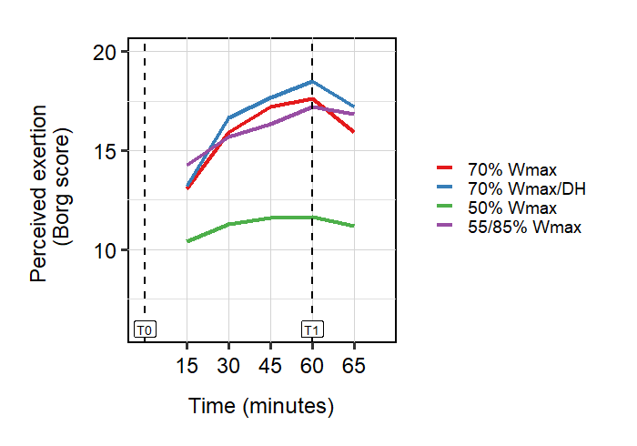

```r
# some further transformation
rpe_grouped <- rpe_scores_clean %>%
#  dplyr::filter(!time == 65) %>%
  dplyr::group_by(protocol, time) %>%
  dplyr::summarize(rpe = mean(rpe, na.rm = TRUE)) %>%
  na.omit()

rpe_plot <- ggplot(rpe_grouped,
                   aes(
                     x = time,
                     y = rpe,
                     group = protocol,
                     color = protocol
                   )) +
  geom_line(size = 1.5) +
  expand_limits(y = c(6, 20),
                x = c(-0.4, 6)) +
  labs(x = "Time (minutes)",
       y = "Perceived exertion \n (Borg score)") +
  geom_vline(xintercept = 4,
             linetype = "dashed",
             size = 1) + ## because time is a factor use the ith element on the axis to place the vline +

  geom_vline(xintercept = 0,
             linetype = "dashed",
             size = 1) +
  geom_label(aes(x = 0,
                 y = 6,
                 label = "T0"), colour = "black", size = 5) +
  geom_label(aes(x = 4,
                 y = 6,
                 label = "T1"), colour = "black", size = 5) +

  scale_color_manual(
    name = "Protocols",
    breaks = c("P2", "P3", "P4", "P5"),
    labels = c("70% Wmax",
               "70% Wmax/DH",
               "50% Wmax",
               "55/85% Wmax"),
    values = palette_rpe
  )  +
  kinetics::theme_individual()

rpe_plot
```

## RPE plot, second version

According rebuttal comments we leave time = 65 min. out of plot and analysis.

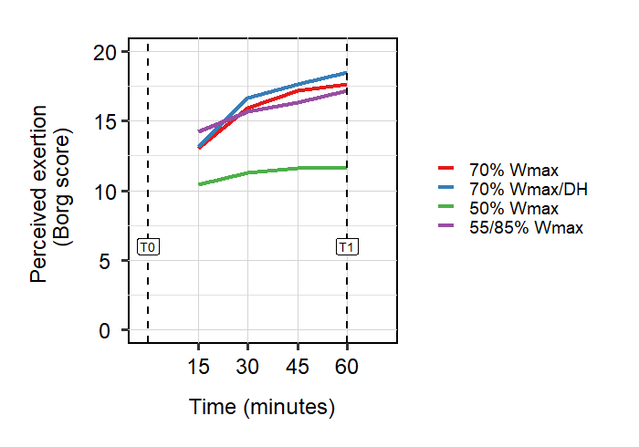

```r
rpe_grouped_rebuttal <- rpe_scores_clean %>%
  dplyr::filter(!time == 65) %>%
  dplyr::group_by(protocol, time) %>%
  dplyr::summarize(rpe = mean(rpe, na.rm = TRUE)) %>%
  na.omit()

## new plot - rebuttal
rpe_plot_rebuttal <- ggplot(rpe_grouped_rebuttal,
                            aes(
                              x = time,
                              y = rpe,
                              group = protocol,
                              color = protocol
                            )) +
  geom_line(size = 1.5) +
  expand_limits(y = c(0, 20),
                x = c(-0.4, 5)) +
  labs(x = "Time (minutes)",
       y = "Perceived exertion \n (Borg score)") +
  geom_vline(xintercept = 4,
             linetype = "dashed",
             size = 1) + ## because time is a factor use the ith element on the axis to place the vline +

  geom_vline(xintercept = 0,
             linetype = "dashed",
             size = 1) +
  geom_label(aes(x = 0,
                 y = 6,
                 label = "T0"),
             colour = "black", size = 5) +
  geom_label(aes(x = 4,
                 y = 6,
                 label = "T1"), colour = "black", size = 5) +

  scale_color_manual(
    name = "Protocols",
    breaks = c("P2", "P3", "P4", "P5"),
    labels = c("70% Wmax",
               "70% Wmax/DH",
               "50% Wmax",
               "55/85% Wmax"),
    values = palette_rpe
  )  +
  kinetics::theme_individual()

rpe_plot_rebuttal
```

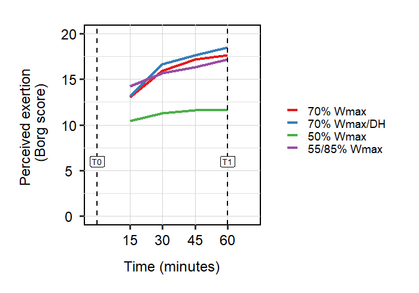

```r
## save plot_rebuttal
ggsave(
  plot = rpe_plot_rebuttal,
  filename = file.path(
    params$path_out,
    paste(Sys.Date(),
          "rpe_plot_rebuttal",
          ".svg",
          sep = "_")
  ),
  width = 11,
  height = 7,
  #  dpi = 300,
  #  units = "cm"
)

ggsave(
  plot = rpe_plot_rebuttal,
   filename = file.path(
    params$path_out,
    paste(Sys.Date(),
          "rpe_plot_rebuttal",
          ".png",
          sep = "_")
  ),
  width = 11,
  height = 7,
  #  dpi = 300,
  #  units = "cm"
)

ggsave(
  plot = rpe_plot_rebuttal,
   filename = file.path(
    params$path_out,
    paste(Sys.Date(),
          "rpe_plot_rebuttal",
          ".jpeg",
          sep = "_")
  ),
  width = 11,
  height = 7,
  #  dpi = 300,
  #  units = "cm"
)

rpe_plot_rebuttal
```

## Statistical analysis of RPE

### Assumptions & Diagnostics

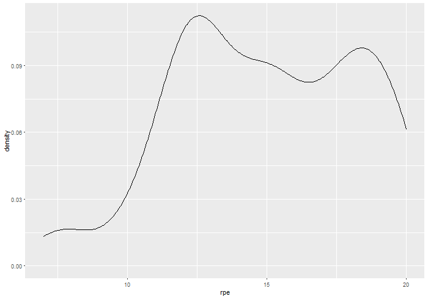

```r
## normality data
rpe_scores_clean %>%
  ggplot(
    aes(
      x = rpe)) +
#  geom_histogram() +
  geom_density()
```

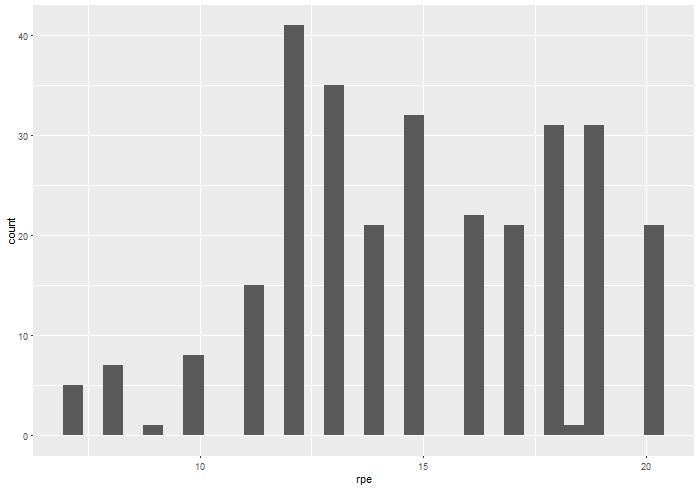

```r
rpe_scores_clean %>%
  ggplot(
    aes(
      x = rpe)) +
  geom_histogram()
```

```r
#  geom_density()

## shapiro - wilk
shapiro.test(rpe_scores$rpe)
```

```
#>
#>  Shapiro-Wilk normality test
#>
#> data:  rpe_scores$rpe
#> W = 0.95562, p-value = 8.649e-08
```

```r
## transforming makes it worse
shapiro.test(log(rpe_scores$rpe))
```

```
#>
#>  Shapiro-Wilk normality test
#>
#> data:  log(rpe_scores$rpe)
#> W = 0.92885, p-value = 1.202e-10
```

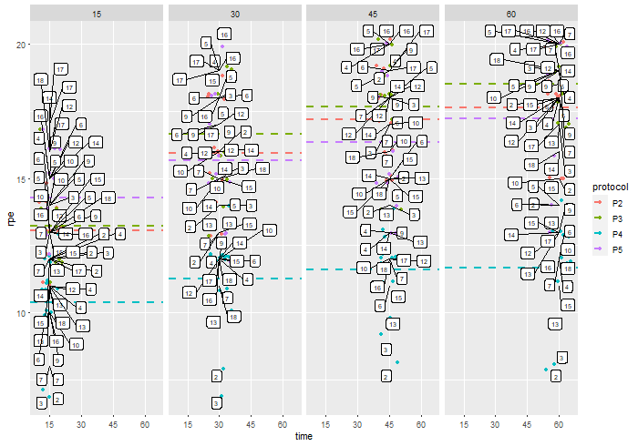

```r
## We will investigate normality of residuals furtheron

## diagnostic plots
## individual observations


rpe_scores_clean %>%
  dplyr::filter(!time == 65) %>%
  ggplot(aes(
    x = time,
    y = rpe)) +
  geom_point(aes(colour = protocol), position = "jitter") +
  geom_hline(
    data = rpe_grouped_rebuttal %>% dplyr::filter(!time == 65),
    aes(
      yintercept = rpe,
      colour = protocol), linetype = "dashed", size = 1) +
  ggrepel::geom_label_repel(aes(label = subject), size = 2.5) +
  facet_wrap(~time, ncol = 4)
```

### Inference

```r
rpe_scores_rebuttal <- rpe_scores %>%
  dplyr::filter(!time == 65,
                !protocol == "P6") %>%
  droplevels()

map(rpe_scores_rebuttal, levels)
```

```
#> $subject
#>  [1] "2"  "3"  "4"  "5"  "6"  "7"  "9"  "10" "12" "13" "14" "15" "16" "17" "18"
#>
#> $protocol
#> [1] "P2" "P3" "P4" "P5"
#>
#> $time
#> [1] "15" "30" "45" "60"
#>
#> $rpe
#> NULL
```

```r
## mixed effects model
 model <-  lme(rpe ~ time * protocol,
                    data = rpe_scores_rebuttal,
                    method = "ML",
                    na.action = "na.omit",
                    random = ~1 | subject)

  # model_summary <- summary(model)
  anova(model)
```

```
#>               numDF denDF   F-value p-value
#> (Intercept)       1   204 1863.4457  <.0001
#> time              3   204   60.6890  <.0001
#> protocol          3   204  157.1189  <.0001
#> time:protocol     9   204    4.3120  <.0001
```

```r
  summary(model)
```

```
#> Linear mixed-effects model fit by maximum likelihood
#>  Data: rpe_scores_rebuttal
#>        AIC      BIC    logLik
#>   910.4164 972.6121 -437.2082
#>
#> Random effects:
#>  Formula: ~1 | subject
#>         (Intercept) Residual
#> StdDev:    1.230163 1.446501
#>
#> Fixed effects: rpe ~ time * protocol
#>                       Value Std.Error  DF   t-value p-value
#> (Intercept)       13.066667 0.5079568 204 25.723974  0.0000
#> time30             2.704043 0.5575005 204  4.850297  0.0000
#> time45             4.133333 0.5472274 204  7.553228  0.0000
#> time60             4.566667 0.5472274 204  8.345099  0.0000
#> protocolP3         0.125927 0.5576312 204  0.225825  0.8216
#> protocolP4        -2.666667 0.5472274 204 -4.873050  0.0000
#> protocolP5         1.200000 0.5472274 204  2.192873  0.0294
#> time30:protocolP3  0.724528 0.7947669 204  0.911623  0.3630
#> time45:protocolP3  0.295238 0.7875947 204  0.374860  0.7082
#> time60:protocolP3  0.719048 0.7875947 204  0.912967  0.3623
#> time30:protocolP4 -1.837377 0.7811944 204 -2.352010  0.0196
#> time45:protocolP4 -2.933333 0.7738964 204 -3.790344  0.0002
#> time60:protocolP4 -3.300000 0.7738964 204 -4.264137  0.0000
#> time30:protocolP5 -1.304043 0.7811944 204 -1.669294  0.0966
#> time45:protocolP5 -2.066667 0.7738964 204 -2.670469  0.0082
#> time60:protocolP5 -1.639906 0.7811944 204 -2.099229  0.0370
#>  Correlation:
#>                   (Intr) time30 time45 time60 prtcP3 prtcP4 prtcP5 t30:P3
#> time30            -0.529
#> time45            -0.539  0.491
#> time60            -0.539  0.491  0.500
#> protocolP3        -0.529  0.481  0.491  0.491
#> protocolP4        -0.539  0.491  0.500  0.500  0.491
#> protocolP5        -0.539  0.491  0.500  0.500  0.491  0.500
#> time30:protocolP3  0.371 -0.701 -0.344 -0.344 -0.700 -0.344 -0.344
#> time45:protocolP3  0.374 -0.341 -0.695 -0.347 -0.706 -0.347 -0.347  0.495
#> time60:protocolP3  0.374 -0.341 -0.347 -0.695 -0.706 -0.347 -0.347  0.495
#> time30:protocolP4  0.377 -0.714 -0.350 -0.350 -0.344 -0.701 -0.350  0.501
```

[output cut: 13 more lines]

```
#> time45:protocolP3
#> time60:protocolP3  0.500
#> time30:protocolP4  0.243  0.243
#> time45:protocolP4  0.491  0.246  0.495
#> time60:protocolP4  0.246  0.491  0.495  0.500
#> time30:protocolP5  0.243  0.243  0.509  0.248  0.248
#> time45:protocolP5  0.491  0.246  0.248  0.500  0.250  0.495
#> time60:protocolP5  0.243  0.487  0.245  0.248  0.495  0.491  0.495
#>
#> Standardized Within-Group Residuals:
#>         Min          Q1         Med          Q3         Max
#> -3.02635445 -0.61496097  0.09045382  0.62802255  2.32806368
#>
#> Number of Observations: 234
#> Number of Groups: 15
```

```r
  ## post hoc
  summary(glht(model, linfct=mcp(time="Tukey")))
```

```
#>
#>   Simultaneous Tests for General Linear Hypotheses
#>
#> Multiple Comparisons of Means: Tukey Contrasts
#>
#>
#> Fit: lme.formula(fixed = rpe ~ time * protocol, data = rpe_scores_rebuttal,
#>     random = ~1 | subject, method = "ML", na.action = "na.omit")
#>
#> Linear Hypotheses:
#>              Estimate Std. Error z value Pr(>|z|)
#> 30 - 15 == 0   2.7040     0.5381   5.025  < 0.001 ***
#> 45 - 15 == 0   4.1333     0.5282   7.826  < 0.001 ***
#> 60 - 15 == 0   4.5667     0.5282   8.646  < 0.001 ***
#> 45 - 30 == 0   1.4293     0.5381   2.656  0.03952 *
#> 60 - 30 == 0   1.8626     0.5381   3.461  0.00285 **
#> 60 - 45 == 0   0.4333     0.5282   0.820  0.84483
#> ---
#> Signif. codes:  0 '***' 0.001 '**' 0.01 '*' 0.05 '.' 0.1 ' ' 1
#> (Adjusted p values reported -- single-step method)
```

```r
  summary(glht(model, linfct=mcp(protocol="Tukey")))
```

```
#>
#>   Simultaneous Tests for General Linear Hypotheses
#>
#> Multiple Comparisons of Means: Tukey Contrasts
#>
#>
#> Fit: lme.formula(fixed = rpe ~ time * protocol, data = rpe_scores_rebuttal,
#>     random = ~1 | subject, method = "ML", na.action = "na.omit")
#>
#> Linear Hypotheses:
#>              Estimate Std. Error z value Pr(>|z|)
#> P3 - P2 == 0   0.1259     0.5382   0.234    0.995
#> P4 - P2 == 0  -2.6667     0.5282  -5.049   <0.001 ***
#> P5 - P2 == 0   1.2000     0.5282   2.272    0.105
#> P4 - P3 == 0  -2.7926     0.5382  -5.188   <0.001 ***
#> P5 - P3 == 0   1.0741     0.5382   1.996    0.189
#> P5 - P4 == 0   3.8667     0.5282   7.321   <0.001 ***
#> ---
#> Signif. codes:  0 '***' 0.001 '**' 0.01 '*' 0.05 '.' 0.1 ' ' 1
#> (Adjusted p values reported -- single-step method)
```

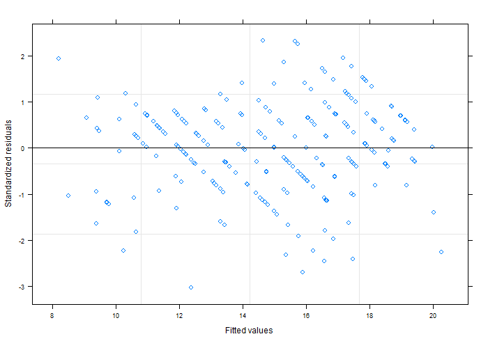

```r
  ## investigate interactions and co-variates
#  rpe_scores_rebuttal$protocol_time_interaction <- interaction(
#    rpe_scores_rebuttal$protocol, rpe_scores_rebuttal$time)
#model <- lme(rpe ~ protocol_time_interaction,
#             random = ~1|subject/protocol/time, data=rpe_scores_rebuttal %>% na.omit())
#comp.timegeno <- glht(model, linfct=mcp(protocol_time_interaction="Tukey"))
#summary(comp.timegeno)


plot(model)
```

## Does the conclusion change if we use a hierachical model with time nested in protocol nested in subject

```r
## mixed effects model
 model2 <-  lme(rpe ~ time * protocol,
                    data = rpe_scores_rebuttal,
                    method = "ML",
                    na.action = "na.omit",
                    random = ~1 | subject/protocol/time) ## add nested structure /pro/tim

  # model_summary <- summary(model)
  anova(model2)
```

```
#>               numDF denDF   F-value p-value
#> (Intercept)       1   163 1850.8162  <.0001
#> time              3   163   80.9464  <.0001
#> protocol          3    41   79.0383  <.0001
#> time:protocol     9   163    5.7404  <.0001
```

```r
  summary(model2)
```

```
#> Linear mixed-effects model fit by maximum likelihood
#>  Data: rpe_scores_rebuttal
#>        AIC      BIC    logLik
#>   894.6289 963.7354 -427.3145
#>
#> Random effects:
#>  Formula: ~1 | subject
#>         (Intercept)
#> StdDev:    1.180445
#>
#>  Formula: ~1 | protocol %in% subject
#>         (Intercept)
#> StdDev:   0.8048094
#>
#>  Formula: ~1 | time %in% protocol %in% subject
#>         (Intercept)  Residual
#> StdDev:    1.150544 0.4993958
#>
#> Fixed effects: rpe ~ time * protocol
#>                       Value Std.Error  DF   t-value p-value
#> (Intercept)       13.066667 0.5085658 163 25.693168  0.0000
#> time30             2.679564 0.4846650 163  5.528694  0.0000
#> time45             4.133333 0.4744975 163  8.710970  0.0000
#> time60             4.566667 0.4744975 163  9.624216  0.0000
#> protocolP3         0.128389 0.5749966  41  0.223286  0.8244
#> protocolP4        -2.666667 0.5637808  41 -4.729970  0.0000
#> protocolP5         1.200000 0.5637808  41  2.128487  0.0394
#> time30:protocolP3  0.749007 0.6900218 163  1.085483  0.2793
#> time45:protocolP3  0.295238 0.6829186 163  0.432318  0.6661
#> time60:protocolP3  0.719048 0.6829186 163  1.052904  0.2939
#> time30:protocolP4 -1.812898 0.6782684 163 -2.672832  0.0083
#> time45:protocolP4 -2.933333 0.6710408 163 -4.371319  0.0000
#> time60:protocolP4 -3.300000 0.6710408 163 -4.917734  0.0000
#> time30:protocolP5 -1.279564 0.6782684 163 -1.886516  0.0610
#> time45:protocolP5 -2.066667 0.6710408 163 -3.079793  0.0024
#> time60:protocolP5 -1.644336 0.6782684 163 -2.424315  0.0164
#>  Correlation:
#>                   (Intr) time30 time45 time60 prtcP3 prtcP4 prtcP5 t30:P3
#> time30            -0.457
#> time45            -0.467  0.490
```

[output cut: 25 more lines]

```
#> time60:protocolP4  0.246  0.491  0.495  0.500
#> time30:protocolP5  0.243  0.243  0.511  0.247  0.247
#> time45:protocolP5  0.491  0.246  0.247  0.500  0.250  0.495
#> time60:protocolP5  0.243  0.486  0.245  0.247  0.495  0.489  0.495
#>
#> Standardized Within-Group Residuals:
#>         Min          Q1         Med          Q3         Max
#> -1.10593499 -0.17225846  0.00681576  0.20020672  1.03746430
#>
#> Number of Observations: 234
#> Number of Groups:
#>                         subject           protocol %in% subject
#>                              15                              59
#> time %in% protocol %in% subject
#>                             234
```

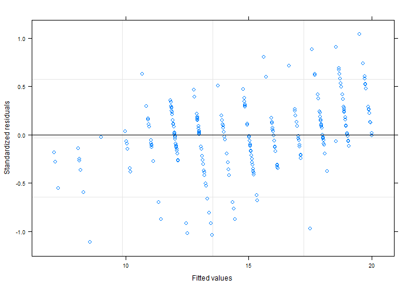

```r
  plot(model2)
```

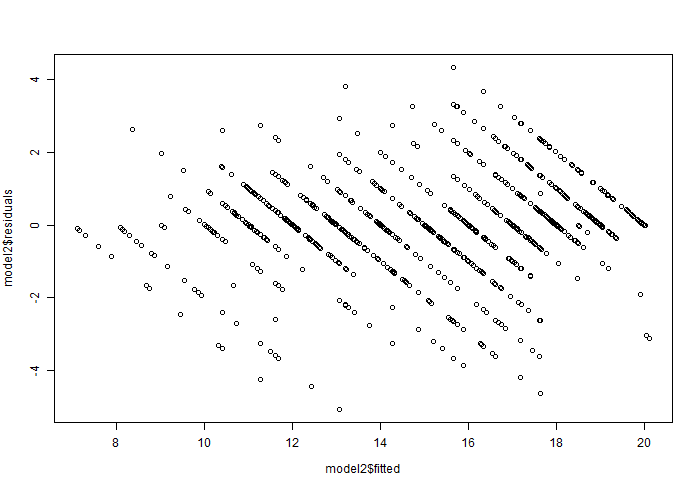

```r
plot(model2$fitted, model2$residuals)
```

```r
## compare models
anova(model, model2)
```

```
#>        Model df      AIC      BIC    logLik   Test  L.Ratio p-value
#> model      1 18 910.4164 972.6121 -437.2082
#> model2     2 20 894.6289 963.7354 -427.3145 1 vs 2 19.78741   1e-04
```

```r
  ## post hoc

  summary(glht(model, linfct=mcp(time="Tukey")))
```

```
#>
#>   Simultaneous Tests for General Linear Hypotheses
#>
#> Multiple Comparisons of Means: Tukey Contrasts
#>
#>
#> Fit: lme.formula(fixed = rpe ~ time * protocol, data = rpe_scores_rebuttal,
#>     random = ~1 | subject, method = "ML", na.action = "na.omit")
#>
#> Linear Hypotheses:
#>              Estimate Std. Error z value Pr(>|z|)
#> 30 - 15 == 0   2.7040     0.5381   5.025  < 0.001 ***
#> 45 - 15 == 0   4.1333     0.5282   7.826  < 0.001 ***
#> 60 - 15 == 0   4.5667     0.5282   8.646  < 0.001 ***
#> 45 - 30 == 0   1.4293     0.5381   2.656  0.03943 *
#> 60 - 30 == 0   1.8626     0.5381   3.461  0.00302 **
#> 60 - 45 == 0   0.4333     0.5282   0.820  0.84483
#> ---
#> Signif. codes:  0 '***' 0.001 '**' 0.01 '*' 0.05 '.' 0.1 ' ' 1
#> (Adjusted p values reported -- single-step method)
```

```r
  summary(glht(model, linfct=mcp(protocol="Tukey")))
```

```
#>
#>   Simultaneous Tests for General Linear Hypotheses
#>
#> Multiple Comparisons of Means: Tukey Contrasts
#>
#>
#> Fit: lme.formula(fixed = rpe ~ time * protocol, data = rpe_scores_rebuttal,
#>     random = ~1 | subject, method = "ML", na.action = "na.omit")
#>
#> Linear Hypotheses:
#>              Estimate Std. Error z value Pr(>|z|)
#> P3 - P2 == 0   0.1259     0.5382   0.234    0.995
#> P4 - P2 == 0  -2.6667     0.5282  -5.049   <0.001 ***
#> P5 - P2 == 0   1.2000     0.5282   2.272    0.105
#> P4 - P3 == 0  -2.7926     0.5382  -5.188   <0.001 ***
#> P5 - P3 == 0   1.0741     0.5382   1.996    0.190
#> P5 - P4 == 0   3.8667     0.5282   7.321   <0.001 ***
#> ---
#> Signif. codes:  0 '***' 0.001 '**' 0.01 '*' 0.05 '.' 0.1 ' ' 1
#> (Adjusted p values reported -- single-step method)
```

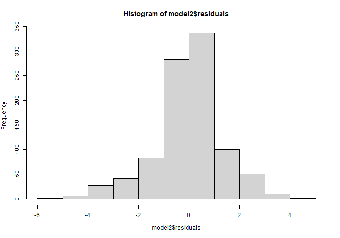

```r
 hist(model2$residuals)
```

```r
 shapiro.test(model2$residuals)
```

```
#>
#>  Shapiro-Wilk normality test
#>
#> data:  model2$residuals
#> W = 0.9554, p-value = 2.934e-16
```

```r
# model_summary <- summary(model)
  anova(model2)
```

```
#>               numDF denDF   F-value p-value
#> (Intercept)       1   163 1850.8162  <.0001
#> time              3   163   80.9464  <.0001
#> protocol          3    41   79.0383  <.0001
#> time:protocol     9   163    5.7404  <.0001
```

```r
  summary(model2)
```

```
#> Linear mixed-effects model fit by maximum likelihood
#>  Data: rpe_scores_rebuttal
#>        AIC      BIC    logLik
#>   894.6289 963.7354 -427.3145
#>
#> Random effects:
#>  Formula: ~1 | subject
#>         (Intercept)
#> StdDev:    1.180445
#>
#>  Formula: ~1 | protocol %in% subject
#>         (Intercept)
#> StdDev:   0.8048094
#>
#>  Formula: ~1 | time %in% protocol %in% subject
#>         (Intercept)  Residual
#> StdDev:    1.150544 0.4993958
#>
#> Fixed effects: rpe ~ time * protocol
#>                       Value Std.Error  DF   t-value p-value
#> (Intercept)       13.066667 0.5085658 163 25.693168  0.0000
#> time30             2.679564 0.4846650 163  5.528694  0.0000
#> time45             4.133333 0.4744975 163  8.710970  0.0000
#> time60             4.566667 0.4744975 163  9.624216  0.0000
#> protocolP3         0.128389 0.5749966  41  0.223286  0.8244
#> protocolP4        -2.666667 0.5637808  41 -4.729970  0.0000
#> protocolP5         1.200000 0.5637808  41  2.128487  0.0394
#> time30:protocolP3  0.749007 0.6900218 163  1.085483  0.2793
#> time45:protocolP3  0.295238 0.6829186 163  0.432318  0.6661
#> time60:protocolP3  0.719048 0.6829186 163  1.052904  0.2939
#> time30:protocolP4 -1.812898 0.6782684 163 -2.672832  0.0083
#> time45:protocolP4 -2.933333 0.6710408 163 -4.371319  0.0000
#> time60:protocolP4 -3.300000 0.6710408 163 -4.917734  0.0000
#> time30:protocolP5 -1.279564 0.6782684 163 -1.886516  0.0610
#> time45:protocolP5 -2.066667 0.6710408 163 -3.079793  0.0024
#> time60:protocolP5 -1.644336 0.6782684 163 -2.424315  0.0164
#>  Correlation:
#>                   (Intr) time30 time45 time60 prtcP3 prtcP4 prtcP5 t30:P3
#> time30            -0.457
#> time45            -0.467  0.490
```

[output cut: 25 more lines]

```
#> time60:protocolP4  0.246  0.491  0.495  0.500
#> time30:protocolP5  0.243  0.243  0.511  0.247  0.247
#> time45:protocolP5  0.491  0.246  0.247  0.500  0.250  0.495
#> time60:protocolP5  0.243  0.486  0.245  0.247  0.495  0.489  0.495
#>
#> Standardized Within-Group Residuals:
#>         Min          Q1         Med          Q3         Max
#> -1.10593499 -0.17225846  0.00681576  0.20020672  1.03746430
#>
#> Number of Observations: 234
#> Number of Groups:
#>                         subject           protocol %in% subject
#>                              15                              59
#> time %in% protocol %in% subject
#>                             234
```

```r
anova(model, model2)
```

```
#>        Model df      AIC      BIC    logLik   Test  L.Ratio p-value
#> model      1 18 910.4164 972.6121 -437.2082
#> model2     2 20 894.6289 963.7354 -427.3145 1 vs 2 19.78741   1e-04
```

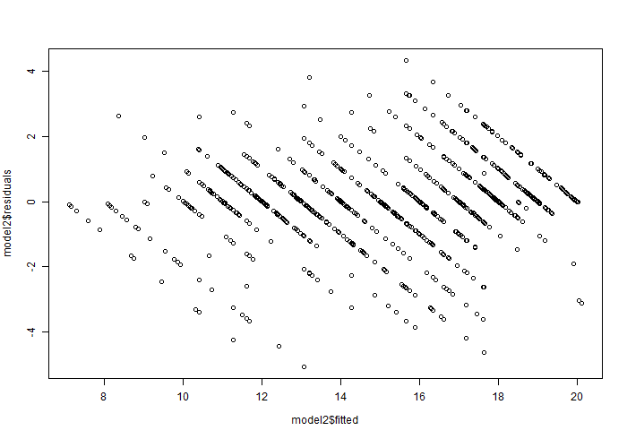

```r
#  plot(model2)

plot(model2$fitted, model2$residuals)
```

```r
  ## post hoc

  summary(glht(model2, linfct=mcp(time="Tukey")))
```

```
#>
#>   Simultaneous Tests for General Linear Hypotheses
#>
#> Multiple Comparisons of Means: Tukey Contrasts
#>
#>
#> Fit: lme.formula(fixed = rpe ~ time * protocol, data = rpe_scores_rebuttal,
#>     random = ~1 | subject/protocol/time, method = "ML", na.action = "na.omit")
#>
#> Linear Hypotheses:
#>              Estimate Std. Error z value Pr(>|z|)
#> 30 - 15 == 0   2.6796     0.4678   5.728   <0.001 ***
#> 45 - 15 == 0   4.1333     0.4580   9.025   <0.001 ***
#> 60 - 15 == 0   4.5667     0.4580   9.971   <0.001 ***
#> 45 - 30 == 0   1.4538     0.4678   3.108   0.0104 *
#> 60 - 30 == 0   1.8871     0.4678   4.034   <0.001 ***
#> 60 - 45 == 0   0.4333     0.4580   0.946   0.7798
#> ---
#> Signif. codes:  0 '***' 0.001 '**' 0.01 '*' 0.05 '.' 0.1 ' ' 1
#> (Adjusted p values reported -- single-step method)
```

```r
  summary(glht(model2, linfct=mcp(protocol="Tukey")))
```

```
#>
#>   Simultaneous Tests for General Linear Hypotheses
#>
#> Multiple Comparisons of Means: Tukey Contrasts
#>
#>
#> Fit: lme.formula(fixed = rpe ~ time * protocol, data = rpe_scores_rebuttal,
#>     random = ~1 | subject/protocol/time, method = "ML", na.action = "na.omit")
#>
#> Linear Hypotheses:
#>              Estimate Std. Error z value Pr(>|z|)
#> P3 - P2 == 0   0.1284     0.5550   0.231    0.996
#> P4 - P2 == 0  -2.6667     0.5442  -4.900   <0.001 ***
#> P5 - P2 == 0   1.2000     0.5442   2.205    0.122
#> P4 - P3 == 0  -2.7951     0.5550  -5.036   <0.001 ***
#> P5 - P3 == 0   1.0716     0.5550   1.931    0.215
#> P5 - P4 == 0   3.8667     0.5442   7.106   <0.001 ***
#> ---
#> Signif. codes:  0 '***' 0.001 '**' 0.01 '*' 0.05 '.' 0.1 ' ' 1
#> (Adjusted p values reported -- single-step method)
```

## Model 3 - simpeler (linear model, unpaired / disregards the paired nature of the experiment)

```r
## lm model
model3 <- lm(rpe ~ time * protocol, data = rpe_scores_rebuttal)
anova(model3)
```

```
#> Analysis of Variance Table
#>
#> Response: rpe
#>                Df  Sum Sq Mean Sq F value  Pr(>F)
#> time            3  409.74  136.58 35.1856 < 2e-16 ***
#> protocol        3 1071.03  357.01 91.9733 < 2e-16 ***
#> time:protocol   9   86.89    9.65  2.4872 0.01007 *
#> Residuals     218  846.20    3.88
#> ---
#> Signif. codes:  0 '***' 0.001 '**' 0.01 '*' 0.05 '.' 0.1 ' ' 1
```

```r
summary(glht(model3, linfct=mcp(protocol="Tukey")))
```

```
#>
#>   Simultaneous Tests for General Linear Hypotheses
#>
#> Multiple Comparisons of Means: Tukey Contrasts
#>
#>
#> Fit: lm(formula = rpe ~ time * protocol, data = rpe_scores_rebuttal)
#>
#> Linear Hypotheses:
#>              Estimate Std. Error t value Pr(>|t|)
#> P3 - P2 == 0   0.1476     0.7321   0.202  0.99709
#> P4 - P2 == 0  -2.6667     0.7194  -3.707  0.00154 **
#> P5 - P2 == 0   1.2000     0.7194   1.668  0.34307
#> P4 - P3 == 0  -2.8143     0.7321  -3.844  < 0.001 ***
#> P5 - P3 == 0   1.0524     0.7321   1.437  0.47743
#> P5 - P4 == 0   3.8667     0.7194   5.375  < 0.001 ***
#> ---
#> Signif. codes:  0 '***' 0.001 '**' 0.01 '*' 0.05 '.' 0.1 ' ' 1
#> (Adjusted p values reported -- single-step method)
```

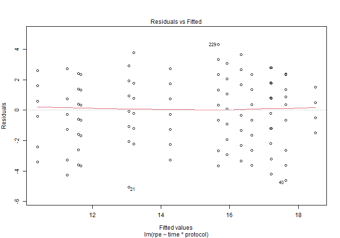

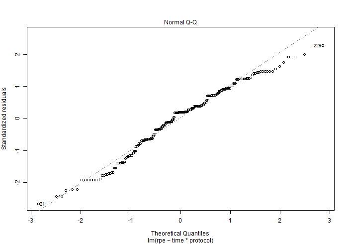

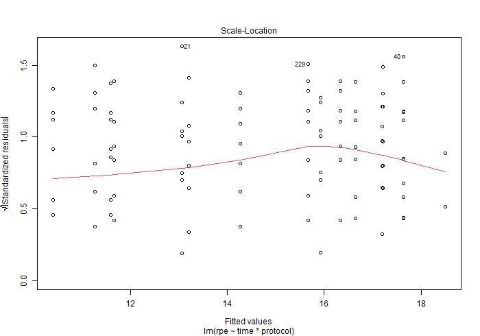

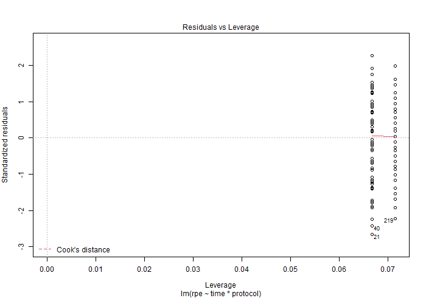

```r
plot(model3)
```

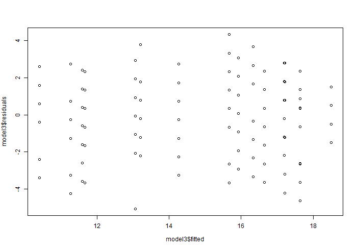

```r
plot(model3$fitted, model3$residuals)
```

```r
## compare models
x <- anova(model, model2, model3)
x
```

```
#>        Model df      AIC       BIC    logLik   Test   L.Ratio p-value
#> model      1 18 910.4164  972.6121 -437.2082
#> model2     2 20 894.6289  963.7354 -427.3145 1 vs 2  19.78741   1e-04
#> model3     3 17 998.8563 1057.5967 -482.4281 2 vs 3 110.22731  <.0001
```

```r
  ## post hoc

  summary(glht(model, linfct=mcp(time="Tukey")))
```

```
#>
#>   Simultaneous Tests for General Linear Hypotheses
#>
#> Multiple Comparisons of Means: Tukey Contrasts
#>
#>
#> Fit: lme.formula(fixed = rpe ~ time * protocol, data = rpe_scores_rebuttal,
#>     random = ~1 | subject, method = "ML", na.action = "na.omit")
#>
#> Linear Hypotheses:
#>              Estimate Std. Error z value Pr(>|z|)
#> 30 - 15 == 0   2.7040     0.5381   5.025  < 0.001 ***
#> 45 - 15 == 0   4.1333     0.5282   7.826  < 0.001 ***
#> 60 - 15 == 0   4.5667     0.5282   8.646  < 0.001 ***
#> 45 - 30 == 0   1.4293     0.5381   2.656  0.03936 *
#> 60 - 30 == 0   1.8626     0.5381   3.461  0.00285 **
#> 60 - 45 == 0   0.4333     0.5282   0.820  0.84483
#> ---
#> Signif. codes:  0 '***' 0.001 '**' 0.01 '*' 0.05 '.' 0.1 ' ' 1
#> (Adjusted p values reported -- single-step method)
```

```r
  summary(glht(model, linfct=mcp(protocol="Tukey")))
```

```
#>
#>   Simultaneous Tests for General Linear Hypotheses
#>
#> Multiple Comparisons of Means: Tukey Contrasts
#>
#>
#> Fit: lme.formula(fixed = rpe ~ time * protocol, data = rpe_scores_rebuttal,
#>     random = ~1 | subject, method = "ML", na.action = "na.omit")
#>
#> Linear Hypotheses:
#>              Estimate Std. Error z value Pr(>|z|)
#> P3 - P2 == 0   0.1259     0.5382   0.234    0.995
#> P4 - P2 == 0  -2.6667     0.5282  -5.049   <0.001 ***
#> P5 - P2 == 0   1.2000     0.5282   2.272    0.105
#> P4 - P3 == 0  -2.7926     0.5382  -5.188   <0.001 ***
#> P5 - P3 == 0   1.0741     0.5382   1.996    0.190
#> P5 - P4 == 0   3.8667     0.5282   7.321   <0.001 ***
#> ---
#> Signif. codes:  0 '***' 0.001 '**' 0.01 '*' 0.05 '.' 0.1 ' ' 1
#> (Adjusted p values reported -- single-step method)
```

## Model 4 - as model 1, but log transformed RPE values

```r
## lm model
 model4 <-  lme(log(rpe) ~ time * protocol,
                    data = rpe_scores_rebuttal,
                    method = "ML",
                    na.action = "na.omit",
                    random = ~1 | subject)

anova(model4)
```

```
#>               numDF denDF   F-value p-value
#> (Intercept)       1   204 11718.401  <.0001
#> time              3   204    51.394  <.0001
#> protocol          3   204   156.721  <.0001
#> time:protocol     9   204     2.730   0.005
```

```r
summary(glht(model4, linfct=mcp(protocol="Tukey")))
```

```
#>
#>   Simultaneous Tests for General Linear Hypotheses
#>
#> Multiple Comparisons of Means: Tukey Contrasts
#>
#>
#> Fit: lme.formula(fixed = log(rpe) ~ time * protocol, data = rpe_scores_rebuttal,
#>     random = ~1 | subject, method = "ML", na.action = "na.omit")
#>
#> Linear Hypotheses:
#>              Estimate Std. Error z value Pr(>|z|)
#> P3 - P2 == 0  0.01817    0.03985   0.456    0.968
#> P4 - P2 == 0 -0.23104    0.03911  -5.908   <0.001 ***
#> P5 - P2 == 0  0.09304    0.03911   2.379    0.081 .
#> P4 - P3 == 0 -0.24921    0.03985  -6.254   <0.001 ***
#> P5 - P3 == 0  0.07486    0.03985   1.879    0.237
#> P5 - P4 == 0  0.32408    0.03911   8.287   <0.001 ***
#> ---
#> Signif. codes:  0 '***' 0.001 '**' 0.01 '*' 0.05 '.' 0.1 ' ' 1
#> (Adjusted p values reported -- single-step method)
```

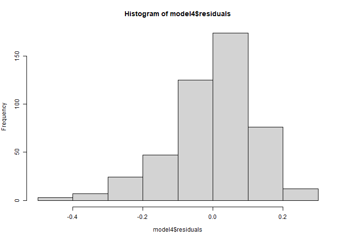

```r
#plot(model4)
#plot(model)

hist(model4$residuals)
```

```r
  ## post hoc

  summary(glht(model, linfct=mcp(time="Tukey")))
```

```
#>
#>   Simultaneous Tests for General Linear Hypotheses
#>
#> Multiple Comparisons of Means: Tukey Contrasts
#>
#>
#> Fit: lme.formula(fixed = rpe ~ time * protocol, data = rpe_scores_rebuttal,
#>     random = ~1 | subject, method = "ML", na.action = "na.omit")
#>
#> Linear Hypotheses:
#>              Estimate Std. Error z value Pr(>|z|)
#> 30 - 15 == 0   2.7040     0.5381   5.025  < 0.001 ***
#> 45 - 15 == 0   4.1333     0.5282   7.826  < 0.001 ***
#> 60 - 15 == 0   4.5667     0.5282   8.646  < 0.001 ***
#> 45 - 30 == 0   1.4293     0.5381   2.656  0.03923 *
#> 60 - 30 == 0   1.8626     0.5381   3.461  0.00306 **
#> 60 - 45 == 0   0.4333     0.5282   0.820  0.84483
#> ---
#> Signif. codes:  0 '***' 0.001 '**' 0.01 '*' 0.05 '.' 0.1 ' ' 1
#> (Adjusted p values reported -- single-step method)
```

```r
  summary(glht(model, linfct=mcp(protocol="Tukey")))
```

```
#>
#>   Simultaneous Tests for General Linear Hypotheses
#>
#> Multiple Comparisons of Means: Tukey Contrasts
#>
#>
#> Fit: lme.formula(fixed = rpe ~ time * protocol, data = rpe_scores_rebuttal,
#>     random = ~1 | subject, method = "ML", na.action = "na.omit")
#>
#> Linear Hypotheses:
#>              Estimate Std. Error z value Pr(>|z|)
#> P3 - P2 == 0   0.1259     0.5382   0.234    0.995
#> P4 - P2 == 0  -2.6667     0.5282  -5.049   <0.001 ***
#> P5 - P2 == 0   1.2000     0.5282   2.272    0.105
#> P4 - P3 == 0  -2.7926     0.5382  -5.188   <0.001 ***
#> P5 - P3 == 0   1.0741     0.5382   1.996    0.190
#> P5 - P4 == 0   3.8667     0.5282   7.321   <0.001 ***
#> ---
#> Signif. codes:  0 '***' 0.001 '**' 0.01 '*' 0.05 '.' 0.1 ' ' 1
#> (Adjusted p values reported -- single-step method)
```

## Model 5 - as model 4, but log transformed RPE values and nested

```r
## lm model
 model5 <-  lme(log(rpe) ~ time * protocol,
                    data = rpe_scores_rebuttal,
                    method = "ML",
                    na.action = "na.omit",
                    random = ~1 | subject/protocol/time)

anova(model5)
```

```
#>               numDF denDF   F-value p-value
#> (Intercept)       1   163 11619.604  <.0001
#> time              3   163    79.284  <.0001
#> protocol          3    41    65.641  <.0001
#> time:protocol     9   163     4.197   1e-04
```

```r
summary(glht(model5, linfct=mcp(protocol="Tukey")))
```

```
#>
#>   Simultaneous Tests for General Linear Hypotheses
#>
#> Multiple Comparisons of Means: Tukey Contrasts
#>
#>
#> Fit: lme.formula(fixed = log(rpe) ~ time * protocol, data = rpe_scores_rebuttal,
#>     random = ~1 | subject/protocol/time, method = "ML", na.action = "na.omit")
#>
#> Linear Hypotheses:
#>              Estimate Std. Error z value Pr(>|z|)
#> P3 - P2 == 0  0.01830    0.04157   0.440    0.971
#> P4 - P2 == 0 -0.23104    0.04075  -5.670   <0.001 ***
#> P5 - P2 == 0  0.09304    0.04075   2.283    0.102
#> P4 - P3 == 0 -0.24934    0.04157  -5.998   <0.001 ***
#> P5 - P3 == 0  0.07474    0.04157   1.798    0.274
#> P5 - P4 == 0  0.32408    0.04075   7.953   <0.001 ***
#> ---
#> Signif. codes:  0 '***' 0.001 '**' 0.01 '*' 0.05 '.' 0.1 ' ' 1
#> (Adjusted p values reported -- single-step method)
```

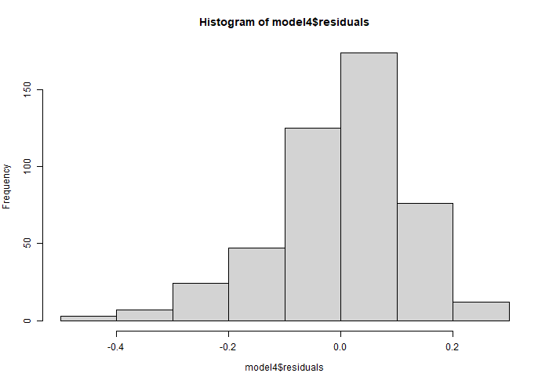

```r
#plot(model5)
#plot(model)

hist(model4$residuals)
```

```r
  summary(glht(model, linfct=mcp(time="Tukey")))
```

```
#>
#>   Simultaneous Tests for General Linear Hypotheses
#>
#> Multiple Comparisons of Means: Tukey Contrasts
#>
#>
#> Fit: lme.formula(fixed = rpe ~ time * protocol, data = rpe_scores_rebuttal,
#>     random = ~1 | subject, method = "ML", na.action = "na.omit")
#>
#> Linear Hypotheses:
#>              Estimate Std. Error z value Pr(>|z|)
#> 30 - 15 == 0   2.7040     0.5381   5.025  < 0.001 ***
#> 45 - 15 == 0   4.1333     0.5282   7.826  < 0.001 ***
#> 60 - 15 == 0   4.5667     0.5282   8.646  < 0.001 ***
#> 45 - 30 == 0   1.4293     0.5381   2.656  0.03938 *
#> 60 - 30 == 0   1.8626     0.5381   3.461  0.00301 **
#> 60 - 45 == 0   0.4333     0.5282   0.820  0.84483
#> ---
#> Signif. codes:  0 '***' 0.001 '**' 0.01 '*' 0.05 '.' 0.1 ' ' 1
#> (Adjusted p values reported -- single-step method)
```

```r
  summary(glht(model, linfct=mcp(protocol="Tukey")))
```

```
#>
#>   Simultaneous Tests for General Linear Hypotheses
#>
#> Multiple Comparisons of Means: Tukey Contrasts
#>
#>
#> Fit: lme.formula(fixed = rpe ~ time * protocol, data = rpe_scores_rebuttal,
#>     random = ~1 | subject, method = "ML", na.action = "na.omit")
#>
#> Linear Hypotheses:
#>              Estimate Std. Error z value Pr(>|z|)
#> P3 - P2 == 0   0.1259     0.5382   0.234    0.995
#> P4 - P2 == 0  -2.6667     0.5282  -5.049   <0.001 ***
#> P5 - P2 == 0   1.2000     0.5282   2.272    0.105
#> P4 - P3 == 0  -2.7926     0.5382  -5.188   <0.001 ***
#> P5 - P3 == 0   1.0741     0.5382   1.996    0.190
#> P5 - P4 == 0   3.8667     0.5282   7.321   <0.001 ***
#> ---
#> Signif. codes:  0 '***' 0.001 '**' 0.01 '*' 0.05 '.' 0.1 ' ' 1
#> (Adjusted p values reported -- single-step method)
```

```r
anova(model4, model5)
```

```
#>        Model df       AIC       BIC   logLik   Test  L.Ratio p-value
#> model4     1 18 -308.7636 -246.5678 172.3818
#> model5     2 20 -341.7466 -272.6402 190.8733 1 vs 2 36.98301  <.0001
```

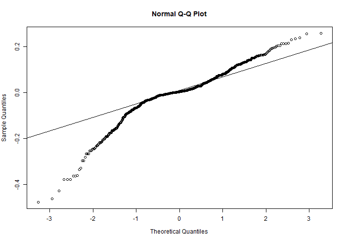

```r
qqnorm(model5$residuals)
qqline(model5$residuals)
```

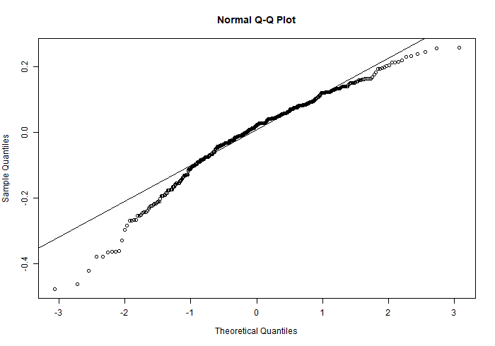

```r
qqnorm(model4$residuals)
qqline(model4$residuals)
```

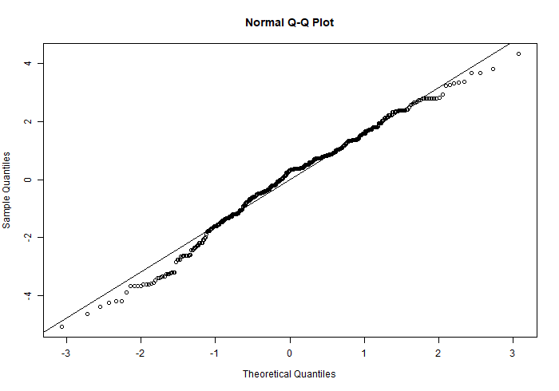

```r
qqnorm(model$residuals)
qqline(model$residuals)
```

## CONCLUSIONS:

The model nummer 1 is the best model (the ‘simple’ mixed effects model) without nesting of subject in protocol in time, where rpe is not log transformed. The anova between the models reveals this as well as the residuals plots and the qqplot of the residuals of model1

```
Model - Fit:
lme.formula(
  fixed = rpe ~ time * protocol,
  data = rpe_scores_rebuttal,
  random = ~1 | subject,
  method = "ML", na.action = "na.omit"
  )
```

The residual plot of model1 shows the least systematic structure

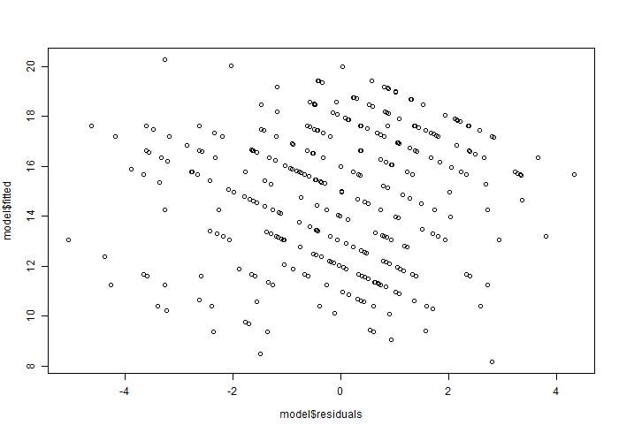

```r
plot(model$residuals, model$fitted)
```

Normality check on the residuals reveals that there is a significant P, which suggests deviation from normality.

H0 for Shapiro -> observations were drawn from a Normal distribution vs H.alt observation were not drawn from a normal distribution.

```r
shapiro.test(model$residuals)
```

```
#>
#>  Shapiro-Wilk normality test
#>
#> data:  model$residuals
#> W = 0.98548, p-value = 0.0001269
```

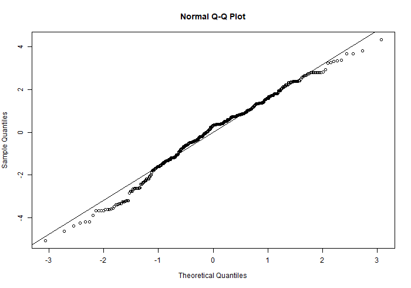

```r
qqnorm(model$residuals)
qqline(model$residuals)
```

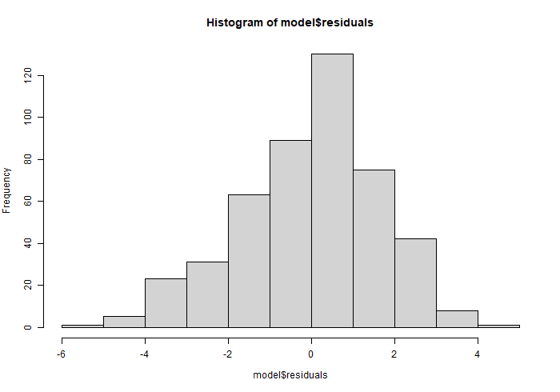

```r
hist(model$residuals) ## the distribution of the residuals is somewhat skewed
```

The models main effects

```r
anova(model)
```

```
#>               numDF denDF   F-value p-value
#> (Intercept)       1   204 1863.4457  <.0001
#> time              3   204   60.6890  <.0001
#> protocol          3   204  157.1189  <.0001
#> time:protocol     9   204    4.3120  <.0001
```

```r
summary(model)
```

```
#> Linear mixed-effects model fit by maximum likelihood
#>  Data: rpe_scores_rebuttal
#>        AIC      BIC    logLik
#>   910.4164 972.6121 -437.2082
#>
#> Random effects:
#>  Formula: ~1 | subject
#>         (Intercept) Residual
#> StdDev:    1.230163 1.446501
#>
#> Fixed effects: rpe ~ time * protocol
#>                       Value Std.Error  DF   t-value p-value
#> (Intercept)       13.066667 0.5079568 204 25.723974  0.0000
#> time30             2.704043 0.5575005 204  4.850297  0.0000
#> time45             4.133333 0.5472274 204  7.553228  0.0000
#> time60             4.566667 0.5472274 204  8.345099  0.0000
#> protocolP3         0.125927 0.5576312 204  0.225825  0.8216
#> protocolP4        -2.666667 0.5472274 204 -4.873050  0.0000
#> protocolP5         1.200000 0.5472274 204  2.192873  0.0294
#> time30:protocolP3  0.724528 0.7947669 204  0.911623  0.3630
#> time45:protocolP3  0.295238 0.7875947 204  0.374860  0.7082
#> time60:protocolP3  0.719048 0.7875947 204  0.912967  0.3623
#> time30:protocolP4 -1.837377 0.7811944 204 -2.352010  0.0196
#> time45:protocolP4 -2.933333 0.7738964 204 -3.790344  0.0002
#> time60:protocolP4 -3.300000 0.7738964 204 -4.264137  0.0000
#> time30:protocolP5 -1.304043 0.7811944 204 -1.669294  0.0966
#> time45:protocolP5 -2.066667 0.7738964 204 -2.670469  0.0082
#> time60:protocolP5 -1.639906 0.7811944 204 -2.099229  0.0370
#>  Correlation:
#>                   (Intr) time30 time45 time60 prtcP3 prtcP4 prtcP5 t30:P3
#> time30            -0.529
#> time45            -0.539  0.491
#> time60            -0.539  0.491  0.500
#> protocolP3        -0.529  0.481  0.491  0.491
#> protocolP4        -0.539  0.491  0.500  0.500  0.491
#> protocolP5        -0.539  0.491  0.500  0.500  0.491  0.500
#> time30:protocolP3  0.371 -0.701 -0.344 -0.344 -0.700 -0.344 -0.344
#> time45:protocolP3  0.374 -0.341 -0.695 -0.347 -0.706 -0.347 -0.347  0.495
#> time60:protocolP3  0.374 -0.341 -0.347 -0.695 -0.706 -0.347 -0.347  0.495
#> time30:protocolP4  0.377 -0.714 -0.350 -0.350 -0.344 -0.701 -0.350  0.501
```

[output cut: 13 more lines]

```
#> time45:protocolP3
#> time60:protocolP3  0.500
#> time30:protocolP4  0.243  0.243
#> time45:protocolP4  0.491  0.246  0.495
#> time60:protocolP4  0.246  0.491  0.495  0.500
#> time30:protocolP5  0.243  0.243  0.509  0.248  0.248
#> time45:protocolP5  0.491  0.246  0.248  0.500  0.250  0.495
#> time60:protocolP5  0.243  0.487  0.245  0.248  0.495  0.491  0.495
#>
#> Standardized Within-Group Residuals:
#>         Min          Q1         Med          Q3         Max
#> -3.02635445 -0.61496097  0.09045382  0.62802255  2.32806368
#>
#> Number of Observations: 234
#> Number of Groups: 15
```

The models pair-wise comparisons see: https://stats.stackexchange.com/questions/5250/multiple-comparisons-on-a-mixed-effects-model

```r
summary(glht(model, linfct=mcp(time="Tukey")))
```

```
#>
#>   Simultaneous Tests for General Linear Hypotheses
#>
#> Multiple Comparisons of Means: Tukey Contrasts
#>
#>
#> Fit: lme.formula(fixed = rpe ~ time * protocol, data = rpe_scores_rebuttal,
#>     random = ~1 | subject, method = "ML", na.action = "na.omit")
#>
#> Linear Hypotheses:
#>              Estimate Std. Error z value Pr(>|z|)
#> 30 - 15 == 0   2.7040     0.5381   5.025  < 0.001 ***
#> 45 - 15 == 0   4.1333     0.5282   7.826  < 0.001 ***
#> 60 - 15 == 0   4.5667     0.5282   8.646  < 0.001 ***
#> 45 - 30 == 0   1.4293     0.5381   2.656  0.03910 *
#> 60 - 30 == 0   1.8626     0.5381   3.461  0.00304 **
#> 60 - 45 == 0   0.4333     0.5282   0.820  0.84484
#> ---
#> Signif. codes:  0 '***' 0.001 '**' 0.01 '*' 0.05 '.' 0.1 ' ' 1
#> (Adjusted p values reported -- single-step method)
```

```r
summary(glht(model, linfct=mcp(protocol="Tukey")))
```

```
#>
#>   Simultaneous Tests for General Linear Hypotheses
#>
#> Multiple Comparisons of Means: Tukey Contrasts
#>
#>
#> Fit: lme.formula(fixed = rpe ~ time * protocol, data = rpe_scores_rebuttal,
#>     random = ~1 | subject, method = "ML", na.action = "na.omit")
#>
#> Linear Hypotheses:
#>              Estimate Std. Error z value Pr(>|z|)
#> P3 - P2 == 0   0.1259     0.5382   0.234    0.995
#> P4 - P2 == 0  -2.6667     0.5282  -5.049   <0.001 ***
#> P5 - P2 == 0   1.2000     0.5282   2.272    0.105
#> P4 - P3 == 0  -2.7926     0.5382  -5.188   <0.001 ***
#> P5 - P3 == 0   1.0741     0.5382   1.996    0.190
#> P5 - P4 == 0   3.8667     0.5282   7.321   <0.001 ***
#> ---
#> Signif. codes:  0 '***' 0.001 '**' 0.01 '*' 0.05 '.' 0.1 ' ' 1
#> (Adjusted p values reported -- single-step method)
```

## Write out statitics to summary file

```r
model_main <- anova(model)
model_contrasts <- list(
  summary(glht(model, linfct=mcp(time="Tukey"))),
  summary(glht(model, linfct=mcp(protocol="Tukey"))))


stargazer::stargazer(model_main)
```

```
#>
#> % Table created by stargazer v.5.2.2 by Marek Hlavac, Harvard University. E-mail: hlavac at fas.harvard.edu
#> % Date and time: vr, aug 21, 2020 - 20:28:21
#> \begin{table}[!htbp] \centering
#>   \caption{}
#>   \label{}
#> \begin{tabular}{@{\extracolsep{5pt}}lccccccc}
#> \\[-1.8ex]\hline
#> \hline \\[-1.8ex]
#> Statistic & \multicolumn{1}{c}{N} & \multicolumn{1}{c}{Mean} & \multicolumn{1}{c}{St. Dev.} & \multicolumn{1}{c}{Min} & \multicolumn{1}{c}{Pctl(25)} & \multicolumn{1}{c}{Pctl(75)} & \multicolumn{1}{c}{Max} \\
#> \hline \\[-1.8ex]
#> numDF & 4 & 4.000 & 3.464 & 1 & 2.5 & 4.5 & 9 \\
#> denDF & 4 & 204.000 & 0.000 & 204 & 204 & 204 & 204 \\
#> F-value & 4 & 521.391 & 896.925 & 4.312 & 46.595 & 583.701 & 1,863.446 \\
#> p-value & 4 & 0.00001 & 0.00002 & 0 & 0 & 0.000 & 0 \\
#> \hline \\[-1.8ex]
#> \end{tabular}
#> \end{table}
```

```r
write_lines(model_main %>% broom::tidy(), path =
                 file.path(
                 params$path_out,
                 "statistics_rpe.txt"))
```

## Heatmaps from model metrics

### Statistical metrics data

Effects sizes and probabilities (F values and P values) were calculated using a multi-level mixed effects model approach as reported earlier ([DOI:(https://doi.org/10.1016/j.clnu.2018.09.029)]) Here we load the F- and P- values for the analytes discussed in the kinetics paper

#### F-values data

```r
data("f_values_long_protocol", package = "kinetics")
f_values_long_protocol
```

```
#> # A tibble: 273 x 3
#>    analyte contrast value
#>    <fct>   <chr>    <dbl>
#>  1 ala     P1_P2    23.7
#>  2 ala     P1_P3    23.9
#>  3 ala     P1_P4     7.65
#>  4 ala     P1_P5    26.5
#>  5 ala     P2_P3    16.3
#>  6 ala     P2_P4    11.2
#>  7 ala     P2_P5     4.83
#>  8 albu    P1_P2    13.8
#>  9 albu    P1_P3    15.0
#> 10 albu    P1_P4     9.39
#> # ... with 263 more rows
```

#### P-values data

```r
data("p_values_long_protocol", package = "kinetics")
p_values_long_protocol
```

```
#> # A tibble: 357 x 4
#>    analyte contrast    value statistic
#>    <fct>   <chr>       <dbl> <chr>
#>  1 ala     P1_P2    1.44e-24 p_value
#>  2 ala     P1_P3    8.23e-25 p_value
#>  3 ala     P1_P4    9.40e- 6 p_value
#>  4 ala     P1_P5    1.45e-27 p_value
#>  5 ala     P2_P3    3.08e-16 p_value
#>  6 ala     P2_P4    3.61e-10 p_value
#>  7 ala     P2_P5    2.83e- 2 p_value
#>  8 alat    P1_P2    5.65e+ 2 p_value
#>  9 alat    P1_P3    1.41e+ 2 p_value
#> 10 alat    P1_P4    8.88e+ 2 p_value
#> # ... with 347 more rows
```

### Inspect data

F- values

```r
names(f_values_long_protocol)
```

```
#> [1] "analyte"  "contrast" "value"
```

```r
levels(f_values_long_protocol$analyte)
```

```
#>  [1] "ala"    "albu"   "arg"    "asp"    "asn"    "bicar"  "chlo"   "citrul"
#>  [9] "cort"   "creat"  "crph"   "eryt"   "facd"   "gfra"   "glu"    "gln"
#> [17] "gly"    "hb"     "ht"     "ifabp"  "ip10"   "ile"    "leu"    "lymph"
#> [25] "lys"    "meth"   "mono"   "neut"   "phe"    "pota"   "ser"    "sodi"
#> [33] "tau"    "thr"    "tnfa"   "trp"    "tyr"    "urea"   "val"
```

```r
f_values_long_protocol$contrast <- as_factor(f_values_long_protocol$contrast)

levels(f_values_long_protocol$contrast)
```

```
#> [1] "P1_P2" "P1_P3" "P1_P4" "P1_P5" "P2_P3" "P2_P4" "P2_P5"
```

```r
f_values_final <- f_values_long_protocol %>%
  mutate(statistic = "f_value") %>%
  print()
```

```
#> # A tibble: 273 x 4
#>    analyte contrast value statistic
#>    <fct>   <fct>    <dbl> <chr>
#>  1 ala     P1_P2    23.7  f_value
#>  2 ala     P1_P3    23.9  f_value
#>  3 ala     P1_P4     7.65 f_value
#>  4 ala     P1_P5    26.5  f_value
#>  5 ala     P2_P3    16.3  f_value
#>  6 ala     P2_P4    11.2  f_value
#>  7 ala     P2_P5     4.83 f_value
#>  8 albu    P1_P2    13.8  f_value
#>  9 albu    P1_P3    15.0  f_value
#> 10 albu    P1_P4     9.39 f_value
#> # ... with 263 more rows
```

P-values

```r
names(p_values_long_protocol)
```

```
#> [1] "analyte"   "contrast"  "value"     "statistic"
```

```r
levels(p_values_long_protocol$analyte)
```

```
#>  [1] "ala"    "alat"   "albu"   "arg"    "asat"   "asn"    "asp"    "bicar"
#>  [9] "chlo"   "citrul" "ck"     "cort"   "creat"  "eryt"   "ggt"    "gln"
#> [17] "glu"    "glu.nn" "gly"    "hb"     "hemo"   "his"    "ht"     "icte"
#> [25] "ifabp"  "ile"    "insu"   "ldh"    "leu"    "leuko"  "lipe"   "lymph"
#> [33] "lys"    "mchc"   "mcv"    "meth"   "mono"   "neut"   "phe"    "pota"
#> [41] "rdw"    "reti"   "ser"    "sodi"   "tau"    "thr"    "trombo" "trp"
#> [49] "tyr"    "urea"   "val"
```

```r
p_values_long_protocol$contrast <- as_factor(p_values_long_protocol$contrast)
levels(p_values_long_protocol$contrast)
```

```
#> [1] "P1_P2" "P1_P3" "P1_P4" "P1_P5" "P2_P3" "P2_P4" "P2_P5"
```

```r
p_values_final <- p_values_long_protocol

ind <- names(f_values_final) == names(p_values_final)
all <- all(ind)
if(all == "FALSE"){
  stop("ERROR, names of dataframes do not match, cannot bind rows - FIX before proceeding")
}
```

Combine F- and P-values

```r
## bind rows
f_and_p <- dplyr::bind_rows(f_values_final,
                            p_values_final) %>%
  print()
```

```
#> # A tibble: 630 x 4
#>    analyte contrast value statistic
#>    <fct>   <fct>    <dbl> <chr>
#>  1 ala     P1_P2    23.7  f_value
#>  2 ala     P1_P3    23.9  f_value
#>  3 ala     P1_P4     7.65 f_value
#>  4 ala     P1_P5    26.5  f_value
#>  5 ala     P2_P3    16.3  f_value
#>  6 ala     P2_P4    11.2  f_value
#>  7 ala     P2_P5     4.83 f_value
#>  8 albu    P1_P2    13.8  f_value
#>  9 albu    P1_P3    15.0  f_value
#> 10 albu    P1_P4     9.39 f_value
#> # ... with 620 more rows
```

```r
levels(as_factor(f_and_p$statistic))
```

```
#> [1] "f_value" "p_value"
```

```r
analytes_f <- f_values_final$analyte %>%
  as_factor() %>%
  levels()

## combine
both <- f_and_p %>%
  dplyr::filter(analyte %in% analytes_f)


analytes_final <- as_factor(both$analyte) %>% levels()
analytes_final
```

```
#>  [1] "ala"    "albu"   "arg"    "asp"    "asn"    "bicar"  "chlo"   "citrul"
#>  [9] "cort"   "creat"  "crph"   "eryt"   "facd"   "gfra"   "glu"    "gln"
#> [17] "gly"    "hb"     "ht"     "ifabp"  "ip10"   "ile"    "leu"    "lymph"
#> [25] "lys"    "meth"   "mono"   "neut"   "phe"    "pota"   "ser"    "sodi"
#> [33] "tau"    "thr"    "tnfa"   "trp"    "tyr"    "urea"   "val"    "alat"
#> [41] "asat"   "ck"     "ggt"    "glu.nn" "hemo"   "his"    "icte"   "insu"
#> [49] "ldh"    "leuko"  "lipe"   "mchc"   "mcv"    "rdw"    "reti"   "trombo"
```

```r
# usethis::use_data(both)
```

## Figure 2

This is the code for the heatmap in Figure 2 of the manuscript

```r
invalid_params <- c("gfra", "ip10", "facd", "crph", "tnfa")


## F-values
heatmap_f_values <- both %>%
  dplyr::filter(statistic == "f_value") %>%
  dplyr::filter(!analyte %in% invalid_params) %>%
  arrange(desc(value))

heatmap_f_values
```

```
#> # A tibble: 238 x 4
#>    analyte contrast value statistic
#>    <fct>   <fct>    <dbl> <chr>
#>  1 lymph   P1_P2     90.9 f_value
#>  2 lymph   P1_P5     90.5 f_value
#>  3 lymph   P1_P3     83.9 f_value
#>  4 lymph   P2_P4     39.4 f_value
#>  5 pota    P1_P2     33.3 f_value
#>  6 bicar   P1_P5     31.7 f_value
#>  7 tyr     P1_P5     30.7 f_value
#>  8 tyr     P1_P2     28.8 f_value
#>  9 bicar   P1_P3     28.4 f_value
#> 10 cort    P2_P4     28.1 f_value
#> # ... with 228 more rows
```

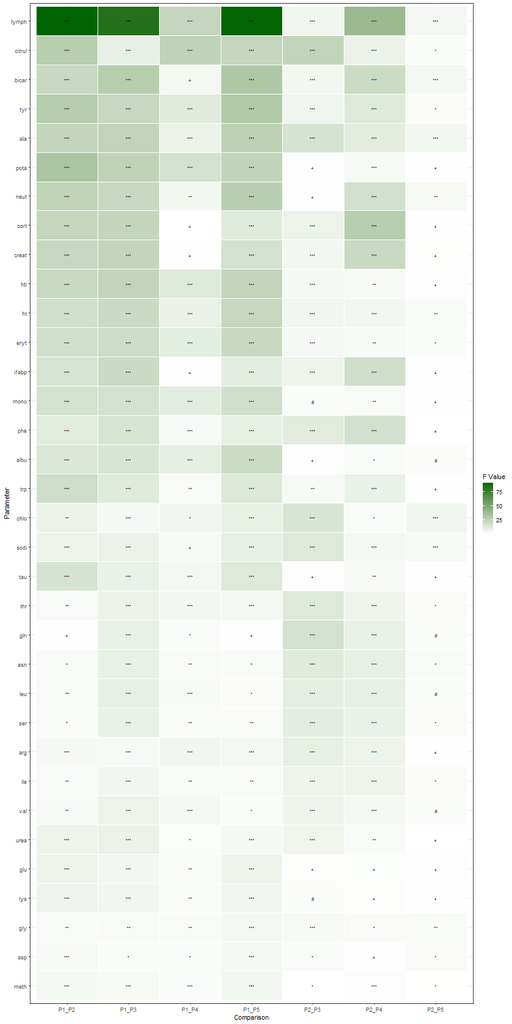

```r
## P-values

## function to convert p-value to stars
signif_num <- function(x) {
    symnum(x, corr = FALSE, na = FALSE, legend = FALSE,
           cutpoints = c(0, 0.001, 0.01, 0.05, 0.1, 1),
           symbols = c("***", "**", "*", "#", "+"))
}

heatmap_p_values <- both %>%
  dplyr::filter(statistic == "p_value") %>%
  dplyr::filter(!analyte %in% invalid_params) %>%
  mutate(
    original_value = (value/1000),
    log10_p = log10(value),
         stars_noquote = signif_num(original_value)) %>%
  mutate(stars = as.character(stars_noquote)) %>%
    arrange(desc(value))

#vheatmap_p_values

#heatmap_p_values %>%
#  dplyr::filter(analyte == "lys")


# checking other duplicates
# names(heatmap_p_values)
x <- heatmap_p_values %>%
  dplyr::select(analyte, contrast) %>%
  group_by(analyte) %>%
  nest()

how_many_contrasts <- function(i){
i %>% nrow()
}

x <- x %>%
  mutate(number_contrasts = map(data, how_many_contrasts))

# x$number_contrasts

#nrow(x)
#unique(x) %>% nrow()

#  as_tibble() %>%
with_stars <- ggplot(data = heatmap_f_values, aes(x = contrast,
              y = reorder(analyte, value))) +
  geom_tile(aes(fill = value), color = "white") +
  scale_fill_gradient(low = "white", high = "darkgreen") +
  geom_text(data = heatmap_p_values,
            aes(label = sprintf("%1.3s", stars)), vjust = 0.6, size = 3) +
  ylab("Parameter") +
  xlab("Comparison") +
  theme(legend.title = element_text(size = 10),
        legend.text = element_text(size = 12),
        plot.title = element_text(size=16),
        axis.title=element_text(size=14,face="bold"),
        axis.text.x = element_text(angle = 90, hjust = 1)) +
   theme(plot.margin=unit(c(2,2,2,2),"cm")) +
  theme_bw() +
  labs(fill = "F Value")

with_stars
```

```r
## save to disk

# ggsave(plot = with_stars,
#         filename = file.path(
#     params$path_out,
#                              paste(Sys.Date(),
#                                    "heatmap_f_values_protocol_with_stars",
#                                    ".svg",
#                                    sep = "_" )
#                              ),
#         width = 24,
#         height = 18,
#         dpi = 600,
#         units = "cm"
#         )

# ggsave(plot = with_stars,
#         filename = file.path(
#     params$path_out,
#                              paste(Sys.Date(),
#                                    "heatmap_f_values_protocol_with_stars",
#                                    ".png",
#                                    sep = "_" )
#                              ),
#         width = 24,
#         height = 18,
#         dpi = 600,
#         units = "cm"
#         )

# ggsave(plot = with_stars,
#         filename = file.path(
#     params$path_out,
#                              paste(Sys.Date(),
#                                    "heatmap_f_values_protocol_with_stars",
#                                    ".jpeg",
#                                    sep = "_" )
#                              ),
#         width = 24,
#         height = 18,
#         dpi = 600,
#         units = "cm"
#         )


# heatmap_p_values$stars_noquote %>% unique()
```

## Some data checking and transformations

```r
histograms <- both %>%
 ggplot(aes(value)) +
  geom_density(aes(y=..density..),
                 colour="black",
                 fill="white") +
  labs(x="Value", y = "Density") +
  theme(legend.position = "none") +
  facet_wrap(~statistic)
histograms
```

```r
histograms <- both %>%
 ggplot(aes(log10(value))) +
  geom_density(aes(y=..density..),
                 colour="black",
                 fill="white") +
  labs(x="Value", y = "Density") +
  theme(legend.position = "none") +
  facet_wrap(~statistic)
histograms
```

```r
histograms <- both %>%
 ggplot(aes(sqrt(value))) +
  geom_density(aes(y=..density..),
                 colour="black",
                 fill="white") +
  labs(x="Value", y = "Density") +
  theme(legend.position = "none") +
  facet_wrap(~statistic)
histograms
```

```r
histograms <- both %>%
 ggplot(aes(value^2)) +
  geom_density(aes(y=..density..),
                 colour="black",
                 fill="white") +
  labs(x="Value", y = "Density") +
  theme(legend.position = "none") +
  facet_wrap(~statistic)
histograms
```

```r
histograms <- both %>%
 ggplot(aes(1/value)) +
  geom_density(aes(y=..density..),
                 colour="black",
                 fill="white") +
  labs(x="Value", y = "Density") +
  theme(legend.position = "none") +
  facet_wrap(~statistic)
histograms
```

```r
heatmap_f_values <- both %>%
  dplyr::filter(statistic == "f_value") %>%
  mutate(sqrt_f = sqrt(value)) %>%
  arrange(desc(value)) %>%

#  as_tibble() %>%
ggplot(., aes(x = contrast,
              y = reorder(analyte, value))) +
  geom_tile(aes(fill = sqrt_f), color = "white") +
  scale_fill_gradient(low = "white", high = "darkgreen") +

  ylab("Analyte") +
  xlab("Contrast") +
  theme(legend.title = element_text(size = 10),
        legend.text = element_text(size = 12),
        plot.title = element_text(size=16),
        axis.title=element_text(size=14,face="bold"),
        axis.text.x = element_text(angle = 90, hjust = 1)) +
   theme(plot.margin=unit(c(2,2,2,2),"cm"))
heatmap_f_values


heatmap_p_values <- both %>%
  dplyr::filter(statistic == "p_value") %>%
  mutate(sqrt_p = sqrt(value)) %>%
  arrange(desc(value)) %>%

#  as_tibble() %>%
ggplot(., aes(x = contrast,
              y = reorder(analyte, desc(value)))) +
  geom_tile(aes(fill = sqrt_p), color = "white") +
  scale_fill_gradient(low = "darkgreen", high = "white") +

  ylab("Analyte") +
  xlab("Contrast") +
  theme(legend.title = element_text(size = 10),
        legend.text = element_text(size = 12),
        plot.title = element_text(size=16),
        axis.title=element_text(size=14,face="bold"),
        axis.text.x = element_text(angle = 90, hjust = 1)) +
   theme(plot.margin=unit(c(2,2,2,2),"cm"))
heatmap_p_values

# scale_y_discrete(limits = rev(levels())) +
#  scale_x_discrete()[order(.$analyte_new_lbl)] +
#  labs(fill = "F value")
#facet_wrap(~ statistic)

heatmap_p_values

panel <- cowplot::plot_grid(heatmap_p_values,
                                         heatmap_f_values,
                            labels = c("A", "B"), vjust = 4, hjust = -8
                            )

panel
 ggsave(plot = panel,
        filename = here::here(
                             "inst",
                             "images",
                             paste(Sys.Date(),
                                   "heatmap_panel_sqrt",
                                   ".svg",
                                   sep = "_" )
                             ),
        width = 40,
        height = 30,
        dpi = 300,
        units = "cm"
        )

ggsave(plot = panel,
        filename = here::here(
                             "inst",
                             "images",
                             paste(Sys.Date(),
                                   "heatmap_panel_sqrt",
                                   ".png",
                                   sep = "_" )
                             ),
        width = 40,
        height = 30,
        dpi = 300,
        units = "cm"
        )

ggsave(plot = panel,
        filename = here::here(
                             "inst",
                             "images",
                             paste(Sys.Date(),
                                   "heatmap_panel_sqrt",
                                   ".jpeg",
                                   sep = "_" )
                             ),
        width = 40,
        height = 30,
        dpi = 300,
        units = "cm"
        )
```

## Prepare data for analyte kinetics graphs

### Load data for analytes

```r
library(kinetics)

data("analyte_data", package = "kinetics")

data_summary <- analyte_data %>%
  arrange(protocol, analyte)
data_summary
```

```
#> # A tibble: 460 x 6
#> # Groups:   protocol, time [40]
#>    protocol time  analyte mean_conc    sd n_obs
#>    <fct>    <fct> <fct>       <dbl> <dbl> <int>
#>  1 P1       0     ALB          44.4  1.96    15
#>  2 P1       0.5   ALB          44.5  2.50    15
#>  3 P1       1     ALB          44.5  3.14    15
#>  4 P1       1.5   ALB          45.1  2.90    14
#>  5 P1       2     ALB          45.3  2.74    15
#>  6 P1       3     ALB          44.7  2.86    15
#>  7 P1       6     ALB          45.2  2.83    15
#>  8 P1       24    ALB          44.7  2.19    15
#>  9 P1       0     BICARB       25.1  1.53    15
#> 10 P1       0.5   BICARB       27.1  2.72    15
#> # ... with 450 more rows
```

```r
data_summary$analyte <- as.factor(data_summary$analyte)
levels(data_summary$analyte)
```

```
#>  [1] "ALB"       "BICARB"    "CHLORIDE"  "ERY"       "GLU_NS"    "HB"
#>  [7] "HT"        "INSULINE"  "KREAT"     "LEUCO"     "POTASSIUM" "SODIUM"
```

```r
data_split <- split(data_summary,
                        droplevels(data_summary$analyte))
```

### Load analyte annotations

```r
data("analyte_annotations", package = "kinetics")
```

## Colours

```r
palette <- RColorBrewer::brewer.pal(7, "Set1")
palette <- c(palette[c(1:3,4,5)])
```

## Line plots

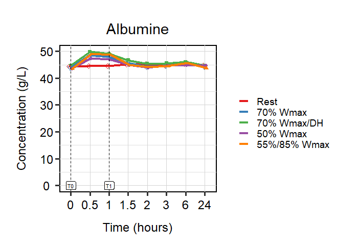

```r
image_directory <- params$loose_images
dir.create(image_directory)

# argument for function test
analyte = "ala"
kinetics::draw_lines(DF = data_split[[1]], palette_graph = palette)
```

```r
test_lines <- print_lines(analyte = "SODIUM")
#test_lines


test_lines <- print_lines(analyte = "INSULINE")
#test_lines

run_plotlist <- function(){
  plot_list <- lapply(levels(data_summary$analyte), print_lines)
  names(plot_list) <- levels(data_summary$analyte)
  names(plot_list)
}
```

## Panels

```r
## test
kinetics::print_lines_panel("GLU_NS", x_pos = c(1,2))
print_lines_panel("POTASSIUM", x_pos = c(1,2))
```

## Prepare potlist for panels

```r
## generate plotlist
analytes <- c(
  "BICARB",
  "KREAT",
  "POTASSIUM",
  "SODIUM",
  "CHLORIDE",
  "ALB",
  "INSULINE",
  "GLU_NS",
  "LEUCO",
  "ERY",
  "HB",
  "HT")

analyte_data <- data_summary %>%
  dplyr::filter(analyte %in% analytes) %>%
  droplevels()

levels(analyte_data$analyte)
```

```
#>  [1] "ALB"       "BICARB"    "CHLORIDE"  "ERY"       "GLU_NS"    "HB"
#>  [7] "HT"        "INSULINE"  "KREAT"     "LEUCO"     "POTASSIUM" "SODIUM"
```

```r
x_pos_list <- list(
  "alb" = c(1,3),
  "bicarb" = c(1,3),
  "chloride" = c(1,3),
  "ery" = c(1,3),
  "glu_ns" = c(1,2), ## the GLU_NS set has less time points
  "hb" = c(1,3),
  "ht" = c(1,3),
  "insuline" = c(1,3),
  "kreat" = c(1,3),
  "leuco" = c(1,3),
  "potassium" = c(1,3),
  "sodium" = c(1,3)
)
x_pos_list
```

```
#> $alb
#> [1] 1 3
#>
#> $bicarb
#> [1] 1 3
#>
#> $chloride
#> [1] 1 3
#>
#> $ery
#> [1] 1 3
#>
#> $glu_ns
#> [1] 1 2
#>
#> $hb
#> [1] 1 3
#>
#> $ht
#> [1] 1 3
#>
#> $insuline
#> [1] 1 3
#>
#> $kreat
#> [1] 1 3
#>
#> $leuco
#> [1] 1 3
#>
#> $potassium
#> [1] 1 3
#>
#> $sodium
#> [1] 1 3
```

```r
## select analytes relevant for kinetics paper - panels
analyte_data <- data_summary %>%
  dplyr::filter(analyte %in% analytes) %>%
  droplevels()

levels(analyte_data$analyte)
```

```
#>  [1] "ALB"       "BICARB"    "CHLORIDE"  "ERY"       "GLU_NS"    "HB"
#>  [7] "HT"        "INSULINE"  "KREAT"     "LEUCO"     "POTASSIUM" "SODIUM"
```

```r
panel_plot_list <- map2(
  .x = levels(analyte_data$analyte),
  .y = x_pos_list,
  .f = print_lines_panel
  )

# panel_plot_list
## check x_pos for GLU_NS
names(panel_plot_list) <- levels(analyte_data$analyte)
names(panel_plot_list)
```

```
#>  [1] "ALB"       "BICARB"    "CHLORIDE"  "ERY"       "GLU_NS"    "HB"
#>  [7] "HT"        "INSULINE"  "KREAT"     "LEUCO"     "POTASSIUM" "SODIUM"
```

```r
## save to disk for use in the package
# usethis::use_data(panel_plot_list)
```

## Final panels

```r
## Panels

## get panel plotlist

#panel_plot_list <- readr::read_rds(
#  path = here::here("data", "panel_plot_list.rds")
#  )

#•  Bicarbonate, kreatinine, potassium, sodium, chloride
#•  Albumine, insulin, glucose
#•  Leukocytes, erythrocytes, Hb, Ht
## read panel_plot_list from disk

#panel_plot_list <- readr::read_rds(path = here::here(
#  "data",
#  "panel_plot_list.rds"
#  ))

# figure 1; panel
p1_a <- panel_plot_list[["BICARB"]]
#p1_a
p1_b <- panel_plot_list[["KREAT"]]
p1_c <- panel_plot_list[["POTASSIUM"]]
p1_e <- panel_plot_list[["SODIUM"]]
p1_d <- panel_plot_list[["CHLORIDE"]]

# figure 2; panel
p2_a <- panel_plot_list[["ALB"]]
p2_b <- panel_plot_list[["INSULINE"]]
p2_c <- panel_plot_list[["GLU_NS"]]

# figure 3; panel
p3_a <- panel_plot_list[["LEUCO"]] + ylab("Counts")
p3_b <- panel_plot_list[["ERY"]] + ylab("Counts")
p3_c <- panel_plot_list[["HB"]]
p3_d <- panel_plot_list[["HT"]]


# figure 4; panel
#p4_a <- panel_plot_list[["CHLORIDE"]]
#p4_b <- panel_plot_list[["ALB"]]
#p4_c <- panel_plot_list[["ERY"]]

## Panels

## dimensions
height <- 12
width <- 12
resolution <- 70
```

## Figure 3

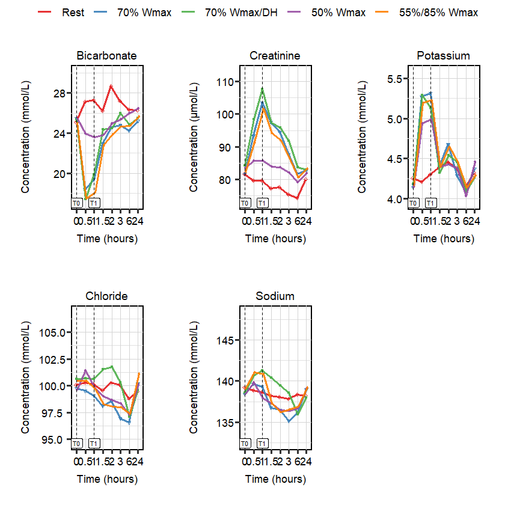

```r
###Figure 1

library(cowplot)
library(svglite)
# https://cran.r-project.org/web/packages/cowplot/vignettes/shared_legends.html

horizontal_label_offset <- -7
vertical_label_offset <- 4
label_size <- 20

figure_1 <- cowplot::plot_grid( p1_a + theme(legend.position="none"),
           p1_b + theme(legend.position="none"),
           p1_c + theme(legend.position="none"),
           p1_d + theme(legend.position="none"),
           p1_e + theme(legend.position="none"),
           align = 'vh',
       #    labels = c("A", "B", "C", "D", "E"),
           hjust = horizontal_label_offset,
           vjust = vertical_label_offset,
           ncol = 3,
           label_size = label_size
           )

#cfigure_1


legend_1 <- get_legend(p1_a + theme(legend.position="bottom"))

p_1 <- plot_grid(legend_1, figure_1, ncol = 1, rel_heights = c(0.05, 1))
p_1
```

```r
## citrulliner::save_in_image_directory(filename = "test2.svg", height = 26, width = 7)
```

```r
ggsave(p_1, filename = file.path(
    params$path_out,
                         paste(Sys.Date(),
                         "kinetics_fig_1.svg", sep = "_")),
       height = height/2.2,
       width = width/1.5,
       dpi = resolution/2)

ggsave(p_1, filename = file.path(
    params$path_out,
                         paste(Sys.Date(),
                         "kinetics_fig_1.png", sep = "_")),
       height = height/2.2,
       width = width/1.5,
       dpi = resolution/2)


ggsave(p_1, filename = file.path(
    params$path_out,
                         paste(Sys.Date(),
                         "kinetics_fig_1.jpeg", sep = "_")),
       height = height/2.2,
       width = width/1.5,
       dpi = resolution/2)
```

## Figure 4

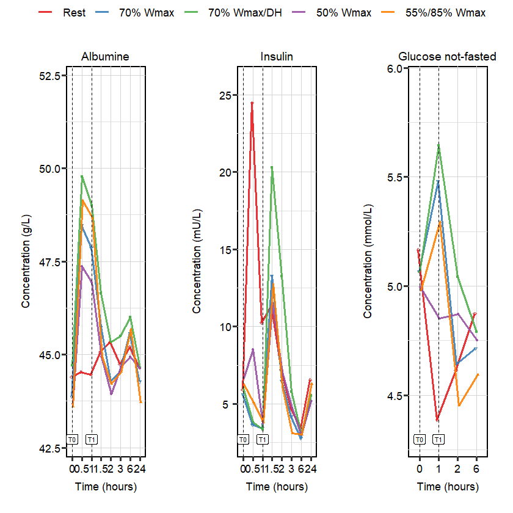

```r
### Figure 2

figure_2 <- plot_grid( p2_a + theme(legend.position="none"),
           p2_b + theme(legend.position="none"),
           p2_c + theme(legend.position="none"),
           align = 'vh',
      #     labels = c("A", "B", "C"),
           hjust = horizontal_label_offset,
           vjust = vertical_label_offset-1,
           ncol = 3,
           label_size = label_size
           )

# figure_2


legend_2 <- get_legend(p2_a + theme(legend.position="bottom"))

p_2 <- plot_grid(legend_2, figure_2, ncol = 1, rel_heights = c(0.05, 1))

p_2
```

```r
## citrulliner::save_in_image_directory(filename = "test2.svg", height = 26, width = 7)
```

```r
ggsave(p_2, filename = file.path(
    params$path_out,
                         paste(Sys.Date(),
                         "kinetics_fig_2.svg", sep = "_")),
       height = height/4.5,
       width = width/1.5,
       dpi = resolution/2)

ggsave(p_2, filename = file.path(
    params$path_out,
                         paste(Sys.Date(),
                         "kinetics_fig_2.png", sep = "_")),
       height = height/4.5,
       width = width/1.5,
       dpi = resolution/2)

ggsave(p_2, filename = file.path(
    params$path_out,
                         paste(Sys.Date(),
                         "kinetics_fig_2.jpeg", sep = "_")),
       height = height/4.5,
       width = width/1.5,
       dpi = resolution/2)
```

### Figure 5

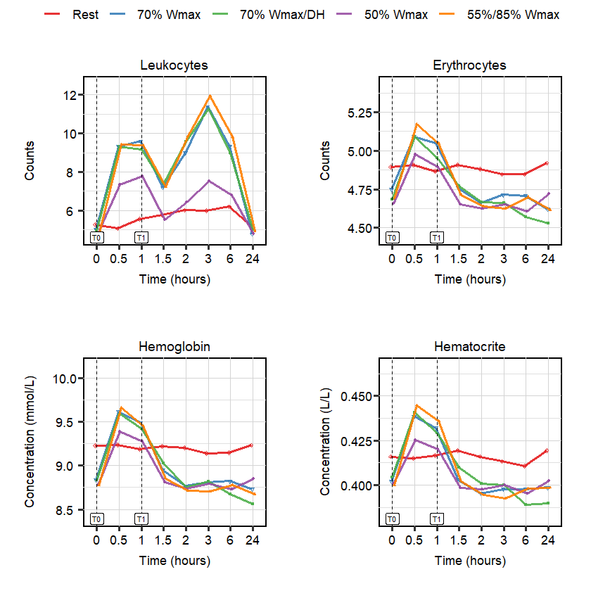

```r
figure_3 <- plot_grid( p3_a + theme(legend.position="none"),
           p3_b + theme(legend.position="none"),
           p3_c + theme(legend.position="none"),
           p3_d + theme(legend.position="none"),
           align = 'vh',
        #   labels = c("A", "B", "C", "D"),
           hjust = horizontal_label_offset,
           vjust = vertical_label_offset,
           ncol = 2,
           label_size = label_size
           )

# figure_3


legend_3 <- get_legend(p3_a + theme(legend.position="bottom"))

p_3 <- plot_grid(legend_3, figure_3, ncol = 1, rel_heights = c(0.05, 1))

## citrulliner::save_in_image_directory(filename = "test2.svg", height = 26, width = 7)
p_3
```

```r
ggsave(p_3, filename = file.path(
    params$path_out,
                         paste(Sys.Date(),
                         "kinetics_fig_3.svg", sep = "_")),
       height = height/2.4,
       width = width/0.4,
       dpi = resolution/2)

ggsave(p_3, filename = file.path(
    params$path_out,
                         paste(Sys.Date(),
                         "kinetics_fig_3.png", sep = "_")),
       height = height/2.4,
       width = width/2.4,
       dpi = resolution/2)


ggsave(p_3, filename = file.path(
    params$path_out,
                         paste(Sys.Date(),
                         "kinetics_fig_3.jpeg", sep = "_")),
       height = height/2.4,
       width = width/2.4,
       dpi = resolution/2)
```

## Summary table

```r
## all analytes in data
unique(data_summary$analyte) %>%
  as.character %>%
  sort %>%
  print()
```

```
#>  [1] "ALB"       "BICARB"    "CHLORIDE"  "ERY"       "GLU_NS"    "HB"
#>  [7] "HT"        "INSULINE"  "KREAT"     "LEUCO"     "POTASSIUM" "SODIUM"
```

```r
analytes_heatmap <- unique(heatmap_f_values$analyte) %>%
  as.character() %>%
  sort() %>%
  print()
```

```
#>  [1] "ala"    "albu"   "arg"    "asn"    "asp"    "bicar"  "chlo"   "citrul"
#>  [9] "cort"   "creat"  "eryt"   "gln"    "glu"    "gly"    "hb"     "ht"
#> [17] "ifabp"  "ile"    "leu"    "lymph"  "lys"    "meth"   "mono"   "neut"
#> [25] "phe"    "pota"   "ser"    "sodi"   "tau"    "thr"    "trp"    "tyr"
#> [33] "urea"   "val"
```

```r
analytes_paper <- c(

  # line figures
  "BICARB", #1

  "KREAT", #2
  "POTASSIUM", #3
  "SODIUM", #4
  "CHLORIDE", #5

  "ALB", #6
  "INSULINE", #7
  "GLU_NS", #8

  "LEUCO", #9
  "ERY", #10
  "HB", #11
  "HT", #12

  ## heatmap
  "ala",
  "arg",
  "asp",
  "asn",
  "citrul",
  "CORT",
  "glu",
  "gln",
  "gly",
  "ifabp",
  "ile",
  "leu",
  "LYMFO_ABS_CORR",
  "lys",
  "meth",
  "MONO_ABS",
  "NEUTRO_ABS",
  "pheala",
  "ser",
  "tau",
  "thre",
  "trp",
  "tyr",
  "UREUM",
  "val"
)

analytes_paper %>% sort
```

```
#>  [1] "ala"            "ALB"            "arg"            "asn"
#>  [5] "asp"            "BICARB"         "CHLORIDE"       "citrul"
#>  [9] "CORT"           "ERY"            "gln"            "glu"
#> [13] "GLU_NS"         "gly"            "HB"             "HT"
#> [17] "ifabp"          "ile"            "INSULINE"       "KREAT"
#> [21] "leu"            "LEUCO"          "LYMFO_ABS_CORR" "lys"
#> [25] "meth"           "MONO_ABS"       "NEUTRO_ABS"     "pheala"
#> [29] "POTASSIUM"      "ser"            "SODIUM"         "tau"
#> [33] "thre"           "trp"            "tyr"            "UREUM"
#> [37] "val"
```

```r
length(analytes_paper)
```

```
#> [1] 37
```

```r
data_paper_summary <- data_summary %>%
  dplyr::filter(analyte %in% analytes_paper) %>%
  print()
```

```
#> # A tibble: 460 x 6
#> # Groups:   protocol, time [40]
#>    protocol time  analyte mean_conc    sd n_obs
#>    <fct>    <fct> <fct>       <dbl> <dbl> <int>
#>  1 P1       0     ALB          44.4  1.96    15
#>  2 P1       0.5   ALB          44.5  2.50    15
#>  3 P1       1     ALB          44.5  3.14    15
#>  4 P1       1.5   ALB          45.1  2.90    14
#>  5 P1       2     ALB          45.3  2.74    15
#>  6 P1       3     ALB          44.7  2.86    15
#>  7 P1       6     ALB          45.2  2.83    15
#>  8 P1       24    ALB          44.7  2.19    15
#>  9 P1       0     BICARB       25.1  1.53    15
#> 10 P1       0.5   BICARB       27.1  2.72    15
#> # ... with 450 more rows
```

```r
unique(data_paper_summary$analyte) %>% as.character() %>% sort %>% length()
```

```
#> [1] 12
```

```r
analytes_paper %>% sort %>% length()
```

```
#> [1] 37
```

```r
analytes_paper %in% unique(data_paper_summary$analyte)
```

```
#>  [1]  TRUE  TRUE  TRUE  TRUE  TRUE  TRUE  TRUE  TRUE  TRUE  TRUE  TRUE  TRUE
#> [13] FALSE FALSE FALSE FALSE FALSE FALSE FALSE FALSE FALSE FALSE FALSE FALSE
#> [25] FALSE FALSE FALSE FALSE FALSE FALSE FALSE FALSE FALSE FALSE FALSE FALSE
#> [37] FALSE
```

```r
## add rpe
rpe_summary <- rpe_scores_clean %>%
  group_by(protocol, time) %>%
 summarise(mean_conc = round(mean(rpe, na.rm = TRUE), digits = 3),
            sd = round(sd(rpe, na.rm = TRUE), digits = 2),
            n_obs = n()) %>%
  dplyr::filter(time != 65) %>%
  dplyr::rename(measured = mean_conc) %>%
  dplyr::mutate(analyte = "RPE") %>%
  dplyr::select(protocol, time, analyte, measured, sd, n_obs)

rpe_summary
```

```
#> # A tibble: 16 x 6
#> # Groups:   protocol [4]
#>    protocol time  analyte measured    sd n_obs
#>    <fct>    <fct> <chr>      <dbl> <dbl> <int>
#>  1 P2       15    RPE         13.1  2.05    15
#>  2 P2       30    RPE         15.9  1.98    15
#>  3 P2       45    RPE         17.2  1.74    15
#>  4 P2       60    RPE         17.6  2.14    15
#>  5 P3       15    RPE         13.2  1.48    15
#>  6 P3       30    RPE         16.6  1.98    15
#>  7 P3       45    RPE         17.6  1.98    15
#>  8 P3       60    RPE         18.5  1.02    15
#>  9 P4       15    RPE         10.4  1.8     15
#> 10 P4       30    RPE         11.3  1.75    15
#> 11 P4       45    RPE         11.6  1.59    15
#> 12 P4       60    RPE         11.7  1.76    15
#> 13 P5       15    RPE         14.3  1.83    15
#> 14 P5       30    RPE         15.7  2.5     15
#> 15 P5       45    RPE         16.3  2.44    15
#> 16 P5       60    RPE         17.2  2.78    14
```

```r
## REname
data_paper_summary <- data_paper_summary %>%
  dplyr::rename(measured = mean_conc)

## combine RPE with rest
data_paper_summary_all <-
  dplyr::bind_rows(
    rpe_summary,
    data_paper_summary
  ) %>%
  dplyr::rename(mean = measured) %>%
  arrange(protocol, analyte, time)







data_paper_summary_all$analyte %>% unique()
```

```
#>  [1] "ALB"       "BICARB"    "CHLORIDE"  "ERY"       "GLU_NS"    "HB"
#>  [7] "HT"        "INSULINE"  "KREAT"     "LEUCO"     "POTASSIUM" "RPE"
#> [13] "SODIUM"
```

```r
## add zonuline
source(
  here::here(
    "R",
    "data_clean_grinta_zonulin.R"
  )
)

zonulin <- data_clean_grinta_zonulin()

## clean op for join
names(data_paper_summary_all)
```

```
#> [1] "protocol" "time"     "analyte"  "mean"     "sd"       "n_obs"
```

```r
zonulin_clean <- zonulin %>%
  dplyr::mutate(time = as.character(time)) %>%
  dplyr::rename(analyte = analyse) %>%
  dplyr::select(subject,
         protocol,
         time,
         analyte,
         result)
zonulin_clean
```

```
#> # A tibble: 200 x 5
#>    subject protocol time  analyte result
#>      <dbl> <chr>    <chr> <chr>    <dbl>
#>  1       2 P1       0     Zonulin  28.8
#>  2       2 P1       1     Zonulin  29.1
#>  3       2 P1       1.5   Zonulin  30.3
#>  4       2 P1       24    Zonulin  28.1
#>  5       3 P1       0     Zonulin  28.6
#>  6       3 P1       1     Zonulin  29.3
#>  7       3 P1       2     Zonulin  32.4
#>  8       3 P1       24    Zonulin  29.1
#>  9       4 P1       0     Zonulin  27.9
#> 10       4 P1       1     Zonulin   6.58
#> # ... with 190 more rows
```

```r
zonulin_summary <- zonulin_clean %>%
  group_by(protocol, time, analyte) %>%
  summarise(mean = round(mean(result, na.rm = TRUE), digits = 3),
            sd = round(sd(result, na.rm = TRUE), digits = 2),
            n_obs = n())


zonulin_summary
```

```
#> # A tibble: 21 x 6
#> # Groups:   protocol, time [21]
#>    protocol time  analyte  mean    sd n_obs
#>    <chr>    <chr> <chr>   <dbl> <dbl> <int>
#>  1 P1       0     Zonulin  28.3  8.38    12
#>  2 P1       1     Zonulin  31.3  8.8     12
#>  3 P1       1.5   Zonulin  30.3 NA        1
#>  4 P1       2     Zonulin  31.5  4.87    11
#>  5 P1       24    Zonulin  31.8  6.25    12
#>  6 P2       0     Zonulin  30.6  7.57    13
#>  7 P2       1     Zonulin  34.7  4.82    13
#>  8 P2       2     Zonulin  31.8  3.12    13
#>  9 P2       24    Zonulin  33.8  4.44    13
#> 10 P3       0     Zonulin  36.7  6.6     12
#> # ... with 11 more rows
```

```r
names(zonulin_summary) == names(data_paper_summary_all)
```

```
#> [1] TRUE TRUE TRUE TRUE TRUE TRUE
```

```r
## row bind zonuline to summary data
data_paper_all_final <- dplyr::bind_rows(
  data_paper_summary_all,
  zonulin_summary
) %>%
arrange(analyte, protocol, time)

data_paper_all_final
```

```
#> # A tibble: 497 x 6
#> # Groups:   protocol [5]
#>    protocol time  analyte  mean    sd n_obs
#>    <chr>    <chr> <chr>   <dbl> <dbl> <int>
#>  1 P1       0     ALB      44.4  1.96    15
#>  2 P1       0.5   ALB      44.5  2.50    15
#>  3 P1       1     ALB      44.5  3.14    15
#>  4 P1       1.5   ALB      45.1  2.90    14
#>  5 P1       2     ALB      45.3  2.74    15
#>  6 P1       24    ALB      44.7  2.19    15
#>  7 P1       3     ALB      44.7  2.86    15
#>  8 P1       6     ALB      45.2  2.83    15
#>  9 P2       0     ALB      43.9  1.85    15
#> 10 P2       0.5   ALB      48.5  2.33    13
#> # ... with 487 more rows
```

```r
# usethis::use_data(data_paper_all_final)

# save to disk
# install.packages("xlsx", dependencies = TRUE)
readr::write_csv(data_paper_all_final,
                 path = file.path(
                   params$path_out,
                 "summary_data_kinetics.csv"
                 )
                 )
```